# CCFRP Angler Survey Analysis

Erin Johnston

changes

```r
library(tidyverse)    ## general
library(here)         ## calling data
library(knitr)        ## general
library(kableExtra)   ## for kable styling
library(patchwork)    ## for combining plots
library(ggsci)        ## for color mixer
library(lemon)        ## for brackets
library(ggpubr)       ## for combining plots & common legend
library(cowplot)      ## plotting images on graph
library(plotrix)      ## standard error function
```

### Summary of changes made in excel

**Please see information script for a full list of changes**

- Changes for question about first year of volunteering:
  - if there was a question mark, question mark was removed
  - if angler started volunteering ‘the first year’, institution was checked. If CP or MLML was the main institution the angler volunteers with ‘the first year’ = 2007. If SIO, UCSB, BML, HSU was the main institutuion, ‘the first year’ = 2017.
  - if the language referred to the number of years volunteered, the year was put as 2021-the anglers response. example ‘8 years ago’ would be 2021-8 = 2013
  - If range of years, the most conservative year was used except if the year was not within the study period (2007-2021)
- Changes for interconnectedness with nature question:
  - Explanation of number erased
  - If range of numbers (only one case), the most conservative number was used

```r
survey_dat <- read_csv(here("Data", "2021-11-17_CCFRP_Angler_Survey_values_corr.csv"))

survey_dat <- survey_dat[-c(1:2),]
##297 responses

names(survey_dat) <- tolower(names(survey_dat))

survey_dat_clean <- survey_dat %>%
  filter(finished == 1,
         distributionchannel != "preview")

survey_dat_clean <- survey_dat_clean %>%
  mutate(unanswered = rowSums(is.na(survey_dat_clean))) %>%
  ## to get rid of the responses where every single question was unanswered.
  filter(unanswered < 55) %>%
  mutate(q1 = as.numeric(q1))
```

Go to top

# Summary of Data

## Section 1) CCFRP Angler Involvement

### 1. What year did you first volunteer with CCFRP?

| q1 | n |
| --- | --- |
| 1999 | 1 |
| 2005 | 1 |
| 2006 | 1 |
| 2007 | 9 |
| 2008 | 4 |
| 2009 | 2 |
| 2010 | 11 |
| 2012 | 6 |
| 2013 | 9 |
| 2014 | 5 |
| 2015 | 6 |
| 2016 | 17 |
| 2017 | 29 |
| 2018 | 44 |
| 2019 | 45 |
| 2020 | 10 |
| 2021 | 22 |
| NA | 7 |

### 2. How often do you volunteer with CCFRP?

**1 = “Every year”**

**2 = “Every few years”**

**3 = "Infrequently (1-2 years only)**

**4 = “Never”**

| q2 | n |
| --- | --- |
| 1 | 150 |
| 2 | 20 |
| 3 | 49 |
| 4 | 10 |

### 3. How many trips have you gone on with CCFRP?

**1 = “1”**

**2 = “2-5”**

**3 = “6-10”**

**4 = “11-19”**

**5 = “20+”**

| q3 | n |
| --- | --- |
| 1 | 52 |
| 2 | 90 |
| 3 | 35 |
| 4 | 27 |
| 5 | 24 |
| NA | 1 |

### 4. What institution have you volunteered with most?

**1 = “Humboldt State University”**

**2 = “Bodega Marine Laboratory”**

**3 = “Moss Landing Marine Laboratories”**

**4 = “Cal Poly SLO”**

**5 = “UC Santa Barbara”**

**6 = “Scripps Institution of Oceanography”**

| q4 | n |
| --- | --- |
| 1 | 20 |
| 2 | 43 |
| 3 | 47 |
| 4 | 33 |
| 5 | 22 |
| 6 | 61 |
| NA | 3 |

### 5. Why did you volunteer to participate on your last CCFRP fishing trip?

**1 = “To enjoy fishing whenever I can”**

**2 = “To fish inside the marine protected areas (MPAs)”**

**3 = “To participate in citizen science”**

**4 = “To give back to fisheries resources”**

**5 = “To learn about rockfish, lingcode, and other species we catch on these trips”**

**6 = “Other (specify)”**

| q5 | n |
| --- | --- |
| 1 | 169 |
| 2 | 122 |
| 3 | 173 |
| 4 | 180 |
| 5 | 136 |
| 6 | 44 |

*NOTE: this was a select all question. Multiple answers were separated and counted.*

#### Additional responses to Question 5

| q5_6_text |
| --- |
| Be on a boat |
| Because Jay is one of the coolest people I’ve met since I’ve been in California. Also… CLIMATE CHANGE. |
| Calico bass sandbass |
| Dedicated to a safe experience |
| Engage in mpa science, conservation |
| enjoy working and seeing the research crews |
| Enjoyed working with Lyall |
| Evaluate role and value of citizen science conducted in a rigorous scientific framework. |
| First of all I was invited. Otherwise it is multi faceted. The last trip was interesting to me because of local. Boat and captain. And Jay and other biologist are very knowledgeable and I always learn… |
| good volunteer research experience |
| help evaluate conservation efforts |
| I’m always learning and relearning |
| I enjoy being on a boat in the ocean. |
| I enjoy the opportunity to teach a few things,to the researchers too |
| I enjoy the science and learning. |
| I feel it is of critical importance to gain as much data as we can to help manage our fisheries. |
| I respect the people involved with the project. |
| I wanted to see first hand how the MPA closures affected specific areas |
| I would do anything to help our ocean |
| Love of marine biology |
| Meeting fellow “fishermen scientists” |
| Renewed my faith in science and the younger generation. |
| See old colleagues |
| Specifically interested in Cape Mendocino MPA and adjacent areas. |
| support a researcher |
| Time on the ocean |
| To assist in ocean preservation and and learn more about the fishery. |
| To educate myself firsthand on the current status’ of MPAs on the California coast. |
| To enjoy all of the experiences on the trip (ie. birds, marine mammals) not just fishing. |
| to hang out with friends |
| To help validate the need for and benefits from MPAs |
| To Help with Research |
| To help with the science of monitoring the fisheries. |
| To learn about the impact we make in the water and learn how this research helps us move toward the right direction |
| To learn about the research being done. |
| To learn about what you are studying and a free fishing trip. |
| To learn more about the ocean. |
| To meet the staff and add to their research by being one of the fishermen |
| To see how the research in the closed areas was being conducted. |
| To see if the marine closures are doing as intended. |
| To see the if MPAs are working. |
| to show support representing NTVP team from California Dept of Fish and WIldlife |
| Very interested in MPA monitoring |
| Volunteer with meaningful long term study that founded watershed to plate possibilities in land and marine assets |
| NA |

### 6. Did you learn anything while volunteering with CCFRP that you found useful?

**1 = “I learned more about the wide range of fish species caught in this area”**

**2 = “I learned what a marine protected area is”**

**3 = “I learned where I am not allowed to go fishing”**

**4 = “I learned how to identify nearhore fish species”**

**5 = “I learned how fishing data can be used in fisheries management”**

**6 = “I learned about techniques to descend groundfish”**

**7 = “I learned how MPAs can be used to manage fisheries”**

**8 = “I did not learn anything”**

**9 = “Other (specify)”**

| q6 | n |
| --- | --- |
| 1 | 136 |
| 2 | 74 |
| 3 | 56 |
| 4 | 110 |
| 5 | 173 |
| 6 | 156 |
| 7 | 119 |
| 8 | 6 |
| 9 | 40 |

*NOTE: this was a select all question. Multiple answers were separated and counted.*

#### Additional responses to Question 6

| q6_9_text |
| --- |
| Always educational to observe the different catch rates based on the different presentations. |
| Attended special events held |
| Better understanding of the metric system and some Latin. |
| Boats, engagement, values to long term studies |
| Constant learning adventure. |
| effectiveness of barbless hooks |
| Hard work will pay off… |
| Have not been out with the research go up yet |
| How dedicated researchers are. |
| I got to know Grant and his team, I saw some of the most scenic coast line and learned how fishing (state) regulations relates to data collected from these trips . |
| I have worked on many other fish data collecting trips, where I gained much of the information above. |
| I learned a lot about the rockfish population and have also gained a lot of respect for rockfish. I had no idea how old they live to be, or that some are live bearing, or spend their whole lives in a … |
| I learned about the amazing dedication of Dean Wendt, Grant Waltz, and others who have kept this important work alive. |
| I learned about what they record and why they record it. As well as what species are of intrest. |
| I learned how rigorous the monitoring protocol was |
| I learned how the MPAs were not based off of much science at all and most of them were created because of money. I was at many of the original meetings to oppose the establishment of the MPAs and here… |
| I learned Jellyfish blooms are high. Seems as if this was present on 2014 and could be attributed to higher water temps and fertilizer/excess chemical runoff. |
| I learned that a lot of really dedicated young people are working hard to conserve our ocean resources |
| I learned that staff really need to develop better trainings for our CCFRP folks prior to sending them out on a commercial vessel. Training in handling fish, fish ID etc needs to be completed before t… |
| I learned to be a more efficient fisher person. |
| I learned what research plan was applied to recording data what would be reliable and valid |
| I personally fish a lot so understand |
| I was able to observe the techiniques for mapping and species location. |
| Improved my fishing techniques |
| In favor of MPAs |
| It appears (with a cursory look at the data) the population and size of the fish are larger in the MPA’s than the reference areas. |
| Learn to fish and not kill the fish |
| Learned about the other research being conducted for example the water born DNA sampling conducted simultaneously with our drifts. Also learned more about the internships, the university affiliations … |
| Learned how to identify male from female fish from anal area; learned the different terminologies to describe condition of the fish when collected ( stomach in mouth, stomach out of mouth, eyes popped… |
| learned to be sociable with everybody |
| Many things beyond your list. We spotted rare dolphins one time among other things. Also learning the ins and outs of new harbors interested me. |
| MPAs - Sustain, protect, and increase domestic seafood supply. Maintain and enhance recreational and subsistence fishing opportunities. Protect ecosystem health and sustainability. Create jobs, suppor… |
| Plan to go on first trip |
| the long bureaucratic process entailed with starting and maintaining a program like this |
| This is my first journey. |
| Unless properly managed, our fisheries are doomed!! |
| Value of MPA’s to fisheries |
| What a freakin deacon is! Sebastes diaconus! |
| Work as a marine biologist so it is nice to see how others do sampling |
| Working together to achieve conservation goal |
| NA |

### 7. I used the following resources to learn about the data collected by CCFRP:

**1 = “CCFRP data briefings at the end of a trip”**

**2 = “Reading the annual volunteer newsletter”**

**3 = “Attending Volunteer Appreciation and Data Workshops if/when offered”**

**4 = “I am not interested in learning about the data that CCFRP collects”**

| q7 | n |
| --- | --- |
| 1 | 170 |
| 2 | 151 |
| 3 | 85 |
| 4 | 9 |
| NA | 11 |

*NOTE: this was a select all question. Multiple answers were separated and counted.*

### 8. I have told my recreational fishing buddies about CCFRP.

**1 = “Yes”**

**2 = “No”**

| q8 | n |
| --- | --- |
| 1 | 215 |
| 2 | 13 |
| NA | 1 |

Go to top

## Section 2) Marine Protected Areas

### 9. **Before** volunteering with CCFRP, what was your general opinion of the creation of MPAs in California? My general opinion or MPA creation was …

**1 = “Positive”**

**2 = “Somewhat positive”**

**3 = “Neither positive nor negative”**

**4 = “Somewhat negative”**

**5 = “Negative”**

**6 = “No Opinion”**

| q9 | n |
| --- | --- |
| 1 | 100 |
| 2 | 41 |
| 3 | 31 |
| 4 | 27 |
| 5 | 16 |
| 6 | 14 |

### 10. **Before** volunteering with CCFRP, did you believe the creation of MPAs would affect the size/abundance of groundfish inside MPAs?

**1 = “Yes, I believed there would be an *increase* in the size of groundfish inside MPAs”**

**2 = “Yes, I believed there would be an *increase* in the abundance of groundfish inside MPAs”**

**3 = “Yes, I believed there would be a *decrease* in the size of groundfish inside MPAs”**

**4 = “Yes, I believed there would be a *decrease* in the abundance of groundfish inside MPAs”**

**5 = “No, I believed there would be *no effect* on size of groundfish inside MPAs”**

**6 = “No, I believed there would be *no effect* on the abundance of groundfish inside MPAs”**

**7 = “I don’t know”**

**8 = “No opinion”**

| q10 | n |
| --- | --- |
| 1 | 169 |
| 2 | 170 |
| 3 | 1 |
| 4 | 1 |
| 5 | 15 |
| 6 | 14 |
| 7 | 17 |
| 8 | 8 |

*NOTE: this was a select all question. Multiple answers were separated and counted.*

### 11. **After** volunteering with CCFRP, what was your general opinion of the creation of MPAs in California? My general opinion or MPA creation was …

**1 = “Positive”**

**2 = “Somewhat positive”**

**3 = “Neither positive nor negative”**

**4 = “Somewhat negative”**

**5 = “Negative”**

**6 = “No Opinion”**

| q11 | n |
| --- | --- |
| 1 | 159 |
| 2 | 33 |
| 3 | 14 |
| 4 | 10 |
| 5 | 9 |
| 6 | 3 |
| NA | 1 |

### 12. **After** volunteering with CCFRP, did you believe the creation of MPAs would affect the size/abundance of groundfish inside MPAs?

**1 = “Yes, I believed there would be an *increase* in the size of groundfish inside MPAs”**

**2 = “Yes, I believed there would be an *increase* in the abundance of groundfish inside MPAs”**

**3 = “Yes, I believed there would be a *decrease* in the size of groundfish inside MPAs”**

**4 = “Yes, I believed there would be a *decrease* in the abundance of groundfish inside MPAs”**

**5 = “No, I believed there would be *no effect* on size of groundfish inside MPAs”**

**6 = “No, I believed there would be *no effect* on the abundance of groundfish inside MPAs”**

**7 = “I don’t know”**

**8 = “No opinion”**

| q12 | n |
| --- | --- |
| 1 | 187 |
| 2 | 195 |
| 3 | 2 |
| 4 | 2 |
| 5 | 14 |
| 6 | 11 |
| 7 | 6 |
| 8 | 2 |
| NA | 1 |

*NOTE: this was a select all question. Multiple answers were separated and counted.*

### 13. If you believe that California MPA creation affected **groundfish abundance and/or size**, what aspect(s) of MPAs do you believe caused these changes?

**1 = “Location of MPAs”**

**2 = “Size of MPAs”**

**3 = “Enforcement of MPA restrictions”**

**4 = “Planning of MPAs as a network”**

**5 = “MPA protection of a portion of fish populations”**

**6 = “Voluntary compliance with restrictions”**

**7 = “Other”**

**8 = “N/A, I do not believe there is an effect”**

| q13 | n |
| --- | --- |
| 1 | 153 |
| 2 | 122 |
| 3 | 168 |
| 4 | 96 |
| 5 | 138 |
| 6 | 100 |
| 7 | 11 |
| 8 | 8 |
| NA | 2 |

*NOTE: this was a select all question. Multiple answers were separated and counted.*

### 14. In your **opinion**, what is the purpose of a Marine Protected Area?

**1 = “To set aside areas of ocean to conserve, restore, and understand natural biodiversity and ecology of the area”**

**2 = “To provide people the opportunity to experience these areas of the ocean now and into the future”**

**3 = “To restrict industrial uses (seabed mining, oil and gas exploration or drilling, windmill or turbine construction, minerals extraction)”**

**4 = “To prevent overfishing/ overuse/ degradation”**

**5 = “MPAs do not have a purpose”**

**6 = “I have no opinion on the purpose of MPAs”**

| q14 | n |
| --- | --- |
| 1 | 196 |
| 2 | 98 |
| 3 | 132 |
| 4 | 195 |
| 5 | 6 |
| 6 | 1 |
| NA | 1 |

*NOTE: this was a select all question. Multiple answers were separated and counted.*

### 15. Have you ever fished in a Marine Protected Area before it was protected **OR** while volunteering with CCFRP? (If no, skip to section 3)

**1 = “Yes”**

**2 = “No”**

| q15 | n |
| --- | --- |
| 1 | 157 |
| 2 | 70 |
| NA | 2 |

### 16. Think about this when answering a-c: Have you experienced a difference in fishing in an MPA versus outside of an MPA?

### a. I catch more fish when fishing inside…

**1 = “MPAs”**

**2 = “Areas open to fishing”**

**3 = “I don’t know”**

**4 = “No difference”**

| q16 | n |
| --- | --- |
| 1 | 115 |
| 2 | 8 |
| 3 | 11 |
| 4 | 25 |
| NA | 70 |

### b. I catch a greater diversity of fish species when fishing inside…

**1 = “MPAs”**

**2 = “Areas open to fishing”**

**3 = “I don’t know”**

**4 = “No difference”**

| q17 | n |
| --- | --- |
| 1 | 98 |
| 2 | 10 |
| 3 | 18 |
| 4 | 33 |
| NA | 70 |

### c. I catch larger fish when I fish inside…

**1 = “MPAs”**

**2 = “Areas open to fishing”**

**3 = “I don’t know”**

**4 = “No difference”**

| q18 | n |
| --- | --- |
| 1 | 94 |
| 2 | 13 |
| 3 | 24 |
| 4 | 28 |
| NA | 70 |

### 17. What is the **primary** reason you enjoy fishing with CCFRP in an MPA:

**1 = “I have no preference for CCFRP fishing sites (MPA or reference)”**

**2 = “To catch a large fish”**

**3 = “To catch a lot of fish”**

**4 = “To catch a lot of species”**

**5 = “To collect scientific fishing data”**

| q19 | n |
| --- | --- |
| 1 | 25 |
| 2 | 20 |
| 3 | 23 |
| 4 | 17 |
| 5 | 137 |
| NA | 7 |

### 18. Hypothetically, how much would you be willing to pay for one day of catch and release fishing inside an MPA while **NOT** participating on a CCFRP trip?

**1 = “$0”**

**2 = “$1 - $20”**

**3 = “$21 - $50”**

**4 = “$51 - $100”**

**5= “$101 - $500”**

**6 = “>$500”**

| q20 | n |
| --- | --- |
| 1 | 77 |
| 2 | 27 |
| 3 | 43 |
| 4 | 54 |
| 5 | 21 |
| NA | 7 |

Go to top

## Section 3) Natural Resource Conservation

### 19. In general, would you say you are more conservation-minded or less conservation-minded than others in the recreational angling community?

### Compared to the rest of the angling community, I am…

**1 = “More conservation minded”**

**2 = “Similarly conservation minded”**

**3 = “Less conservation minded”**

**4 = “I don’t know”**

| q22 | n |
| --- | --- |
| 1 | 161 |
| 2 | 59 |
| 4 | 9 |

### 20. Do you participate in activities with conservation-oriented groups (separate from CCFRP)?

**1 = “Yes”**

**2 = “No”**

| q23 | n |
| --- | --- |
| 1 | 126 |
| 2 | 102 |
| NA | 1 |

### 21. How informed do you consider yourself to be concerning ocean issues in California?

**1 = “Not well”**

**2 = “Somewhat”**

**3 = “Well”**

**4 = “Very Well”**

**5 = “Unsure”**

| q24 | n |
| --- | --- |
| 1 | 12 |
| 2 | 81 |
| 3 | 73 |
| 4 | 60 |
| 5 | 3 |

### 22. In what ways do you currently obtain information about ocean related issues? Select all that apply.

**1 = “CCFRP related events (Volunteer Appreciation/ Data Workshops)”**

**2 = “Newspaper”**

**3 = “Magazine”**

**4 = “Family/Friends”**

**5 = “Radio”**

**6 = “Internet”**

**7 = “Social Media”**

**8 = “Television”**

**9 = “Other”**

**10 = “I have not sought out information on ocean related issues”**

| q25 | n |
| --- | --- |
| 1 | 132 |
| 10 | 4 |
| 2 | 111 |
| 3 | 86 |
| 4 | 100 |
| 5 | 44 |
| 6 | 186 |
| 7 | 81 |
| 8 | 55 |
| 9 | 68 |
| NA | 2 |

*NOTE: this was a select all question. Multiple answers were separated and counted.*

### 23. In your opinion, how well are California groundfish stocks managed?

### I believe California groundfish stocks are:

**1 = “Very well managed”**

**2 = “Well managed”**

**3 = “Adequately managed”**

**4 = “Poorly managed”**

**5 = “Very poorly managed”**

**6 = “I don’t believe they are managed at all”**

**7 = “I don’t know”**

| q26 | n |
| --- | --- |
| 1 | 18 |
| 2 | 58 |
| 3 | 81 |
| 4 | 38 |
| 5 | 5 |
| 6 | 3 |
| 7 | 26 |

### 24. Please rank the following types of fishing gear or fishing practices(from 1 to 8) as having the greatest impact on the degradation of the marine environment or reduction in fish stocks. (1 is least impact and 8 is greatest impact).

Traps or pots

| q27_1 | n |
| --- | --- |
| 1 | 15 |
| 2 | 39 |
| 3 | 42 |
| 4 | 31 |
| 5 | 23 |
| 6 | 25 |
| 7 | 22 |
| 8 | 15 |
| NA | 17 |

Hook and line, recreational

| q27_2 | n |
| --- | --- |
| 1 | 37 |
| 2 | 66 |
| 3 | 28 |
| 4 | 30 |
| 5 | 15 |
| 6 | 14 |
| 7 | 5 |
| 8 | 2 |
| NA | 32 |

Bottom trawling

| q27_3 | n |
| --- | --- |
| 1 | 2 |
| 2 | 3 |
| 3 | 6 |
| 4 | 6 |
| 5 | 6 |
| 6 | 15 |
| 7 | 33 |
| 8 | 151 |
| NA | 7 |

Longline

| q27_4 | n |
| --- | --- |
| 1 | 2 |
| 2 | 6 |
| 3 | 15 |
| 4 | 17 |
| 5 | 33 |
| 6 | 34 |
| 7 | 43 |
| 8 | 63 |
| NA | 16 |

Gill nets

| q27_5 | n |
| --- | --- |
| 1 | 3 |
| 2 | 2 |
| 3 | 4 |
| 4 | 4 |
| 5 | 14 |
| 6 | 18 |
| 7 | 48 |
| 8 | 128 |
| NA | 8 |

Midwater trawling

| q27_6 | n |
| --- | --- |
| 1 | 1 |
| 2 | 6 |
| 3 | 9 |
| 4 | 22 |
| 5 | 42 |
| 6 | 37 |
| 7 | 53 |
| 8 | 45 |
| NA | 14 |

Hook and line, commercial

| q27_7 | n |
| --- | --- |
| 1 | 7 |
| 2 | 33 |
| 3 | 41 |
| 4 | 45 |
| 5 | 18 |
| 6 | 34 |
| 7 | 19 |
| 8 | 10 |
| NA | 22 |

Spearfishing

| q27_8 | n |
| --- | --- |
| 1 | 72 |
| 2 | 59 |
| 3 | 19 |
| 4 | 13 |
| 5 | 8 |
| 6 | 7 |
| 7 | 1 |
| 8 | 2 |
| NA | 48 |

### 25. This question consists of a chart that queries you on your opinion of potential ocean issues. Statements are rated 1-7. An answer of ‘1’ indicates that you strongly disagree, ‘4’ indicates no opinion, and ‘7’ indicates you strongly agree with the statement.

### Please indicate whether you think any of the following is a threat to California’s marine environment. Please circle ONE number for each.

Water Pollution

| q28_1 | n |
| --- | --- |
| 1 | 3 |
| 2 | 1 |
| 3 | 2 |
| 4 | 1 |
| 5 | 24 |
| 6 | 61 |
| 7 | 134 |
| NA | 3 |

Marine Debris

| q28_2 | n |
| --- | --- |
| 1 | 1 |
| 2 | 5 |
| 3 | 5 |
| 4 | 15 |
| 5 | 38 |
| 6 | 73 |
| 7 | 88 |
| NA | 4 |

Loss of Marine Biodiversity

| q28_3 | n |
| --- | --- |
| 1 | 1 |
| 2 | 2 |
| 3 | 4 |
| 4 | 15 |
| 5 | 29 |
| 6 | 73 |
| 7 | 98 |
| NA | 7 |

Overfishing

| q28_4 | n |
| --- | --- |
| 2 | 5 |
| 3 | 14 |
| 4 | 7 |
| 5 | 45 |
| 6 | 54 |
| 7 | 98 |
| NA | 6 |

Invasive/Exotic Species

| q28_5 | n |
| --- | --- |
| 1 | 2 |
| 2 | 6 |
| 3 | 8 |
| 4 | 22 |
| 5 | 47 |
| 6 | 73 |
| 7 | 67 |
| NA | 4 |

Rising Sea Temperatures

| q28_6 | n |
| --- | --- |
| 1 | 4 |
| 2 | 3 |
| 3 | 9 |
| 4 | 11 |
| 5 | 37 |
| 6 | 52 |
| 7 | 109 |
| NA | 4 |

Oceano Acidification and Hypoxia

| q28_7 | n |
| --- | --- |
| 1 | 1 |
| 2 | 4 |
| 3 | 5 |
| 4 | 36 |
| 5 | 32 |
| 6 | 56 |
| 7 | 91 |
| NA | 4 |

Wave energy/Power development

| q28_8 | n |
| --- | --- |
| 1 | 13 |
| 2 | 23 |
| 3 | 27 |
| 4 | 86 |
| 5 | 42 |
| 6 | 18 |
| 7 | 15 |
| NA | 5 |

Oil/gas exploitation or transport

| q28_9 | n |
| --- | --- |
| 1 | 4 |
| 2 | 9 |
| 3 | 14 |
| 4 | 33 |
| 5 | 38 |
| 6 | 51 |
| 7 | 71 |
| NA | 9 |

### 26. How interconnected are you with nature? (1 - 7, where 1 is completely separated and 7 is completely interconnected)

| q39 | n |
| --- | --- |
| 2 | 1 |
| 3 | 15 |
| 4 | 63 |
| 5 | 72 |
| 6 | 42 |
| 7 | 31 |
| NA | 5 |

Go to top

## Section 4) Basic Demographics

### 27. What is the zip code of your primary residence?

| q30 | n |
| --- | --- |
| 26866 | 1 |
| 36582 | 1 |
| 53955 | 1 |
| 6896 | 1 |
| 85254 | 1 |
| 90254 | 1 |
| 90265 | 2 |
| 90503 | 1 |
| 90638 | 1 |
| 90703 | 2 |
| 90805 | 1 |
| 91320 | 2 |
| 91362 | 1 |
| 91403 | 1 |
| 91745 | 1 |
| 91755 | 1 |
| 91910 | 3 |
| 91911 | 2 |
| 91915 | 1 |
| 92010 | 3 |
| 92019 | 1 |
| 92020 | 1 |
| 92024 | 2 |
| 92026 | 1 |
| 92037 | 3 |
| 92054 | 2 |
| 92058 | 1 |
| 92067 | 2 |
| 92071 | 2 |
| 92078 | 1 |

[output cut: 130 more lines]

### 28. I identify as

**1 = “Male”**

**2 = “Female”**

**3 = “Non-binary”**

**4 = “Prefer not to state”**

**5 = “Other: (specify)”**

| q31 | n |
| --- | --- |
| 1 | 185 |
| 2 | 38 |
| 3 | 1 |
| 4 | 3 |
| 5 | 1 |
| NA | 1 |

| q31_5_text |
| --- |
| Apache attack helicopter (did you seriously ask what I “identify as”?) |
| NA |

### 29. What is your age?

**1 = “18-24”**

**2 = “25-34”**

**3 = “35-44”**

**4 = “45-54”**

**5 = “55-64”**

**6 = “65 years and older”**

| q32 | n |
| --- | --- |
| 1 | 13 |
| 2 | 34 |
| 3 | 23 |
| 4 | 28 |
| 5 | 53 |
| 6 | 76 |
| NA | 2 |

### 30. What is the highest level of education you have completed?

**1 = “Less than high school degree”**

**2 = “High school degree or equivalent (e.g., GED)”**

**3 = “Associate degree or completion of technical or professional school”**

**4 = “Some college but no degree”**

**5 = “Bachelor degree”**

**6 = “Graduate degree (e.g., Master degree. PhD, JD, MD, etc.)”**

| q33 | n |
| --- | --- |
| 2 | 12 |
| 3 | 28 |
| 4 | 33 |
| 5 | 97 |
| 6 | 56 |
| NA | 3 |

### 31. Which of the following categories best describes your household’s total annual income before taxes in 2020?

**1 = “Less than $25,000”**

**2 = “$25,000 - $34,999”**

**3 = “$35,000 - $49,999”**

**4 = “$50,000 - $74,999”**

**5 = “$75,000 - $99,999”**

**6 = “$100,000 - $149,999”**

**7 = “$150,000 - $199,999”**

**8 = “$200,000 or more”**

**9 = “Decline to state”**

| q34 | n |
| --- | --- |
| 1 | 10 |
| 2 | 13 |
| 3 | 16 |
| 4 | 28 |
| 5 | 35 |
| 6 | 42 |
| 7 | 27 |
| 8 | 24 |
| 9 | 29 |
| NA | 5 |

### 32. Have you or anyone you know ever worked in marine resource management at the local, state, federal, or academic level. Select all that apply. (e.g., CA Department of Fish and Wildlife or NOAA)

**1 = “Yes, self”**

**2 = “Yes, family”**

**3 = “Yes, friend”**

**4 = “No”**

| q35 | n |
| --- | --- |
| 1 | 42 |
| 2 | 26 |
| 3 | 94 |
| 4 | 100 |
| NA | 2 |

*NOTE: this was a select all question. Multiple answers were separated and counted.*

### 33. Have you ever worked in the recreational fishing industry? (e.g., a captain, boat crew, bait or tackle salesperson, etc.)

**1 = “Yes”**

**2 = “No”**

| q36 | n |
| --- | --- |
| 1 | 52 |
| 2 | 174 |
| NA | 3 |

### 34. Have you ever worked in the commercial fishing industry? (e.g., a fisherman, captain, boat crew, buyer, etc.)

**1 = “Yes”**

**2 = “No”**

| q37 | n |
| --- | --- |
| 1 | 31 |
| 2 | 195 |
| NA | 3 |

### 35. Additional space is provided below for any additional comments or concerns regarding this survey.

| q38 |
| --- |
| #32 Volunteered at State fishery (feeding and stocking)for several years. |
| a concern about the number of catches ,500, made in the MPA in one trip. If that is an accurate number it seems excessive.? |
| Am concerned by the “theoretical” supposition of paying to fish an MPA. Shouldn’t be allowed at all |
| Answer to #32. Volunteer work for Manatee wildlife protection (Federal) |
| Any viable work toward understanding our marine fisheries is worthwhile. I have given up fishing after over 65 years of involvement after realizing fish are victims. If I had it my way, there would be… |
| Appreciate studies and efforts of the CCFRP. Hopefully the studies will help in preserving the the fishing and habitat for future generations to enjoy. |
| Ask in the survey - Ranking about the demand for seafood and its impact on the exploitation of fisheries, and the environment |
| Awesome research and form if data collection |
| Based on the number of very specific questions, it would be fairly easy to figure out who answered these questions. Some do not seem relevant and ask for fairly personal information. |
| Fished in the Bodega Mpa. I think that particular mpa was and is not a great fishery |
| Fuck covid |
| Great |
| Great program |
| Great program and wonderful people. I’m honored to be able to participate! |
| How is it being determined that the larger numbers of fish caught in many of the MPA sites is because of there being more fish, as opposed to less pressured fish that are more willing to bite? |
| I’m disturbed by Ms Reiss-Boyd’s affiliation with western states petroleum and her approval/recommendations/allowances for oil extraction inside SoCal MPA’S. This seems like a glaring conflict of inte… |
| I appreciate being able to participate in the CFR program and taking this survey. Having fished all over California for the last 50 years, I thought i knew it all. But I have discovered that there is … |
| I believe in science based fishery management. |
| I believe that california Dept of Fish and Wildlife has been doing a great job in managing our fisheries over the years. The stocks are just fine. Sizes are just fine. The MPA’s only close down the be… |
| I believe that the decrease in the fishery is mostly attributed to the commercial vessels/long liners. The recreational anglers take is minute in comparison to the commercial fishing companies. |
| I believe that the establishment of MPAs is important to conserve and study the natural resources of our ocean. I do however suggest that a greater amount of input from the angling public should be ta… |
| I get what you are trying to do here. Identify your volunteer demographic a nd profile their mindset. Not too fond of being profiled |
| I heard about this volunteer work on KHUM radio, contacted CFR via email within minutes of broadcast. Waited for quite sometime to participate, due to COVID. I was very pleased to be a part of it and … |
| I love CCFRP! |
| I think there are better ways than protected areas. Data has shown that catch and release is a viable option. Specific seasons as well. The excuse that the can not be enforced is not backed by data, b… |
| I try to go every year, but did take a few years off. |
| I want to get back out there to fish for this program again. |
| I was stakeholder in the NC MLPA process |
| I work in terrestrial conservation, spatial analytics and conservation biology |
| I would love to see the results of this data you’re capturing |
| I would recommend that in the education survey question, you put an option for Trade School. |
| It is always to hear and listen to results of all the trips involved with CCFRP, a wonderful learning opportunity for a lay person. |
| Keep up the amazing work |
| keep up the good work. Pleas send updates in the marine world |
| Keep up the good work…Thanks |
| Keep up the MPA surveys, 10years of data is just scratching the surface. Decades of data will be needed to demonstrate the effects of MPAs. |
| Let our voices be heard and be effective in wildlife conservation programs |
| MPA’s serve a meaningful purpose, but they are shamefully disregarded on a large scale, possibly due to lack of enforcement of violators. |
| MPA location affects the abundance and size of catch. Presence of and abundance of local wild life and change in weather and natural circumstances have huge effect on number and size of catch within t… |
| MPAs are needed as a way of supporting intact ecosystems and fish populations. They present study opportunities in many ways in science and management. |
| MPAS have put additional pressure on resources. The fishing pressure that would normally be distributed throughout an area that now has a MLPA has caused smaller fish due to constant pressure. After t… |
| My overall experience fishing with CCFRP has been very positive. |
| Need WATER |
| Nothing more to say |
| Pls let me know if can be of any further assistance |
| Questions 18 and 26 are different. |
| Re-selection, or revision of marine protection area boundaries to include more prime habitat for key species would be a desirable management decision. |
| Some of the first few questions could not be properly responded to due to the fact I have not yet had the opportunity to come help out the research team just yet. |
| Thank you |
| Thank you for all you do to study, educate, and protect our resourcs. |
| Thank you for doing this work! |
| Thank you for the work you do. There should be a zero-take limit on barred sand bass. Recreational fishing for this slow-to-grow species during their annual spawning run has perilously depleted their … |
| Thank you guys for the fantastic work you do!!! |
| Thank you! |
| Thanks everyone for making this possible! Awesome program. |
| Thanks for the great work you do and helping people learn about and conserve valuable marine resources. |
| Thanks for the survey. Continue the fish counts. Hoping our efforts assist in better decisions for improved fishery management. |
| Thanks, and great survey! Good luck and hope to be on a trip again soon,, post-Covid! |
| The more we know, the better suited we are to manage. |
| the program is great and very beneficial. Thanks for letting me participate! |
| The question about how much would you pay to go fishing in MPA catch and release not with CCFRP, this seems to imply that there is a future possibility of people paying some fee to fish in a MPA, I th… |
| There are some questions I would have answered no opinion but did not have that option |
| These trips made me fall in love deeper with fishing and has made more conscious of my environment |
| Very proud to be a volunteer |
| very well thought of |
| What has happened in Laguna Beach with it being a designated MPA is a travisty to us local long time fisherman.Salt Creak and below to Camp Pendleton is getting over fished because that area is closed… |
| When I was supposed rank 1-8 on impacts on marine life, Couldn’t enter what I wanted that question should be tossed. |
| Without effective engagement with fishermen, scientists, resource managers, and the general public, our California Marine Protected Areas (MPAs), will be lost. Marine species will be lost forever. Fut… |
| Would like to participate in a workshop |
| NA |

Go to top

# Preliminary Figures for Snapshot Analysis

All graphs are set up the same way - Standard ggplot grey color, larger font size etc. These are the graphs that made it into the google doc/snapshot analysis.

**FONT SIZE**

To change the size of the percentages above bars, change the `size` argument in `geom_text()`. To change the size of the axis title or text, change the `size` argument inside of the `theme()` function –this should be the last function on the end of each ggplot.

**PLOT COLOR**

-For bars that are all one color: include a `fill` and `color` argument inside of `geom_col()`, but OUTSIDE of the aestheic function `aes()`. Assign a fill and color using hexidecimal ggplot colors. Examples are ‘#000666’, #CC6600’ which have to be in quotes. You can find all the colors here: http://www.cookbook-r.com/Graphs/Colors_(ggplot2)/.

-For bars that are different colors, assign the colors manually. Add a `fill` and `color` argument INSIDE of `aes()` inside of `geom_col()`. Then add two more functions to ggplot: `scale_fill_manual()` and `scale_color_manual()` with the designated colors inside.

**ORIENTATION**

To turn the bars horizonally, add the function `coord_flip()` to ggplot

### **CCFRP Angler Involvement: QUESTION 1**

### **QUESTION 2**

```r
trip_freq <- c("Every year", "Every few years", "Infrequently (1-2 years)", "Never")

ss2 <- survey_dat_clean %>% select(q2) %>% drop_na() %>% count(q2 = factor(q2))%>%
    mutate(pct = n/sum(n)*100,
           pct = round(pct, digits = 0))%>%
  ggplot(aes(x = q2, y = pct, label = paste0(pct, "%")))+
  geom_col(position = "dodge")+
  geom_text(position = position_dodge(width = 0.9),
            vjust = -0.5,
            size = 4)+
  scale_y_continuous(limits = c(0,75)) +
  scale_x_discrete(labels = trip_freq) +
  labs(x = '\nHow often do you volunteer with CCFRP?', y = 'Percent') +
  theme_bw() +
  theme(panel.grid = element_blank(),
        legend.position = "none",
        axis.title=element_text(size=12),
        axis.text = element_text(size = 12))
```

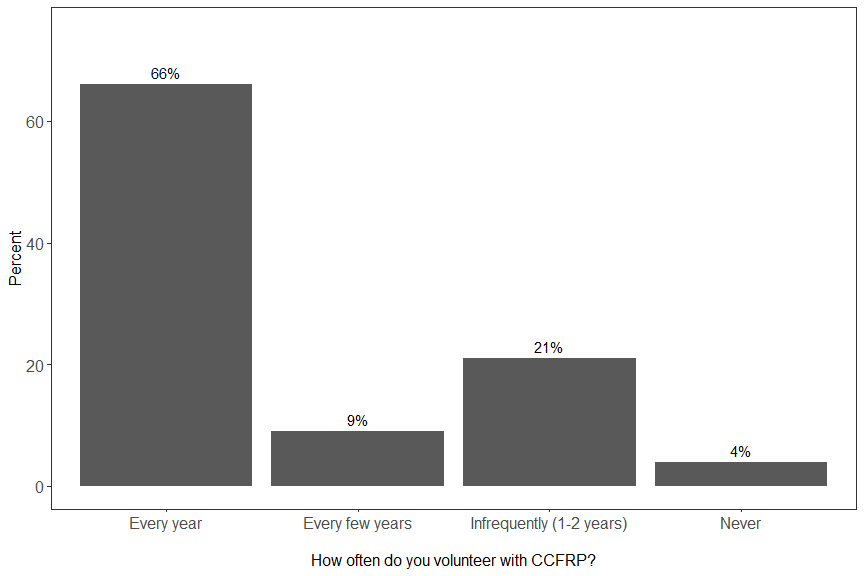

```r
ss2
```

### **QUESTION 3**

```r
trip_num <- c("1", "2-5", "6-10", "11-19", "20+")

ss3 <- survey_dat_clean %>% select(q3) %>% drop_na() %>% count(q3 = factor(q3))%>%
    mutate(pct = n/sum(n)*100,
           pct = round(pct, digits = 0))%>%
  ggplot(aes(x = q3, y = pct, label = paste0(pct, "%")))+
  geom_col(position = "dodge")+
  geom_text(position = position_dodge(width = 0.9),
            vjust = -0.5,
            size = 4)+
  scale_y_continuous(limits = c(0,50)) +
  scale_x_discrete(labels = trip_num) +
  labs(x = '\nHow many trips have you gone on with CCFRP?', y = 'Percent') +
  theme_bw() +
  theme(panel.grid = element_blank(),
        legend.position = "none",
        axis.title=element_text(size=12),
        axis.text = element_text(size = 12))
```

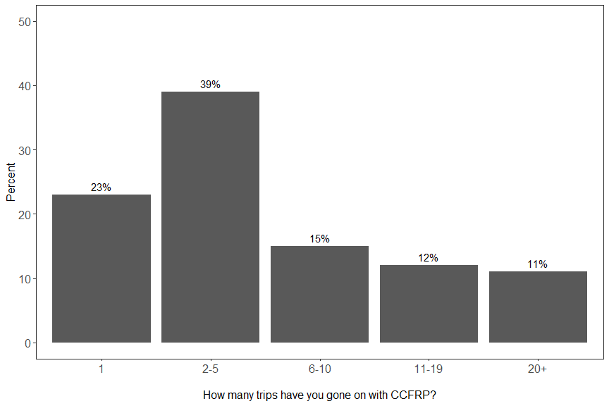

```r
ss3
```

### **QUESTION 4**

```r
institution <- c("Humboldt State \nUniversity", "Bodega Marine \nLaboratory",
                 "Moss Landing \nMarine Laboratories", "Cal Poly SLO",
                 "UC Santa Barbara", "Scripps Institution \nof Oceanography")

ss4 <- survey_dat_clean %>% select(q4) %>% drop_na() %>% count(q4 = factor(q4))%>%
    mutate(pct = n/sum(n)*100,
           pct = round(pct, digits = 0))%>%
  ggplot(aes(x = q4, y = pct, label = paste0(pct, "%")))+
  geom_col(position = "dodge")+
  geom_text(position = position_dodge(width = 0.9),
            vjust = -0.5,
            size = 4)+
  scale_y_continuous(limits = c(0,50)) +
  scale_x_discrete(labels = institution) +
  labs(x = '\nWhat institution have you volunteered with most?', y = 'Percent') +
  theme_bw() +
  theme(panel.grid = element_blank(),
        legend.position = "none",
        axis.title=element_text(size=12),
        axis.text = element_text(size = 12))
```

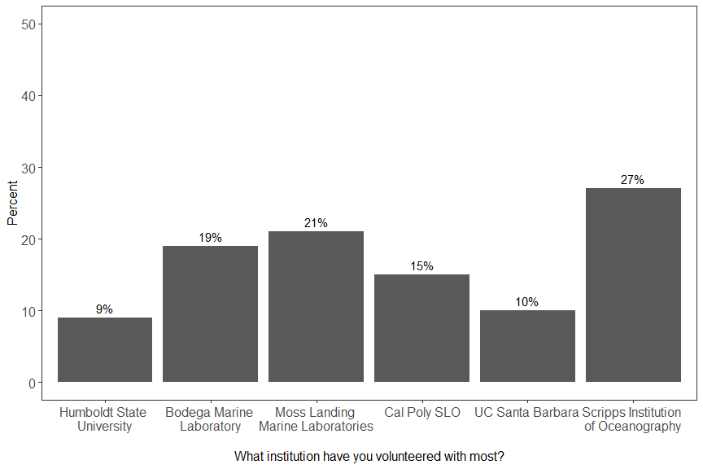

```r
ss4
```

### **QUESTION 5**

```r
## length(survey_dat_clean$q5_6_text[!is.na(survey_dat_clean$q5_6_text)])

why_volunteer <- c("Enjoy \nfishing", "Fish inside \nMPAs", "Citizen \nscience", "Give back \nto fisheries \nresources", "Learn about \nfish species", "Other")

ss5 <- survey_dat_clean %>%
  select(q5) %>%
  drop_na() %>%
  separate_rows(q5) %>%
  count(q5 = factor(q5))%>%
  mutate(pct = n/sum(!is.na(survey_dat_clean$q5))*100,
         pct = round(pct, digits = 1))%>%
  ggplot(aes(x = q5, y = pct, label = paste0(pct, "%")))+
  geom_col(position = "dodge")+
  geom_text(position = position_dodge(width = 0.9),
            vjust = -0.5,
            size = 4)+
  scale_y_continuous(limits = c(0,90)) +
  scale_x_discrete(labels = why_volunteer) +
  #coord_flip()+
  labs(x = '\nWhy did you volunteer on your last CCFRP trip?', y = 'Percent') +
  theme_bw() +
  theme(panel.grid = element_blank(),
        legend.position = "none",
        axis.title=element_text(size=12),
        axis.text = element_text(size = 12))
```

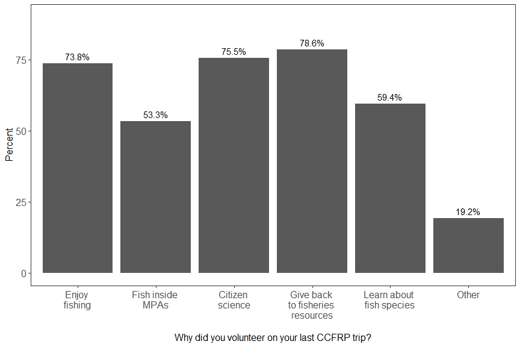

```r
ss5
```

### **QUESTION 6**

```r
## length(survey_dat_clean$q5_6_text[!is.na(survey_dat_clean$q5_6_text)])

learned <- c("Fish \nSpecies", "What \nMPAs are", "Where I \ncan fish", "ID nearshore \nfishes", "Fisheries \nmanagement", "Descending \ntechniques", "How MPAs \nare used", "I did not \nlearn anything", "Other")

ss6 <- survey_dat_clean %>%
  select(q6) %>%
  drop_na() %>%
  separate_rows(q6) %>%
  count(q6 = factor(q6))%>%
  mutate(pct = n/sum(!is.na(survey_dat_clean$q6))*100,
         pct = round(pct, digits = 0))%>%
  ggplot(aes(x = q6, y = pct, label = paste0(pct, "%")))+
  geom_col(position = "dodge")+
  geom_text(position = position_dodge(width = 0.9),
            vjust = -0.5,
            size = 4)+
  scale_y_continuous(limits = c(0,90)) +
  scale_x_discrete(labels = learned) +
  labs(x = '\nWhat did you learn while volunteering with CCFRP?', y = 'Percent') +
  theme_bw() +
  theme(panel.grid = element_blank(),
        legend.position = "none",
        axis.title=element_text(size=12),
        axis.text = element_text(size = 12))
```

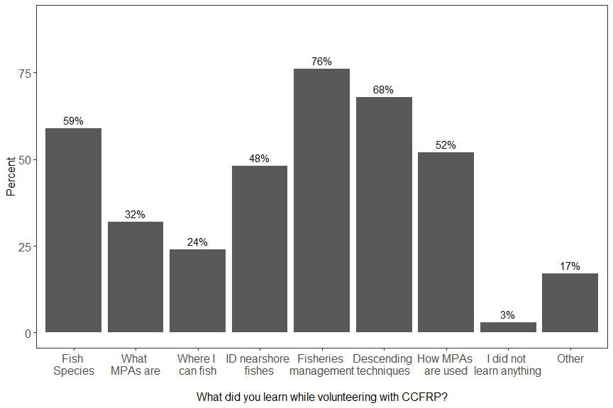

```r
ss6
```

### **QUESTION 7**

```r
resources <- c("CCFRP \ndata briefings", "Annual \nvolunteer newsletter", "Volunteer \ndata workshops", "I am \nnot interested")

ss7 <- survey_dat_clean %>%
  select(q7) %>%
  drop_na() %>%
  separate_rows(q7) %>%
  count(q7 = factor(q7))%>%
  mutate(pct = n/sum(!is.na(survey_dat_clean$q7))*100,
         pct = round(pct, digits = 0))%>%
  ggplot(aes(x = q7, y = pct, label = paste0(pct, "%")))+
  geom_col(position = "dodge")+
  geom_text(position = position_dodge(width = 0.9),
            vjust = -0.5,
            size = 4)+
  scale_y_continuous(limits = c(0,90)) +
  scale_x_discrete(labels = resources) +
  labs(x = '\nResources used to learn about the data collected by CCFRP', y = 'Percent') +
  theme_bw() +
  theme(panel.grid = element_blank(),
        legend.position = "none",
        axis.title=element_text(size=12),
        axis.text = element_text(size = 12))
```

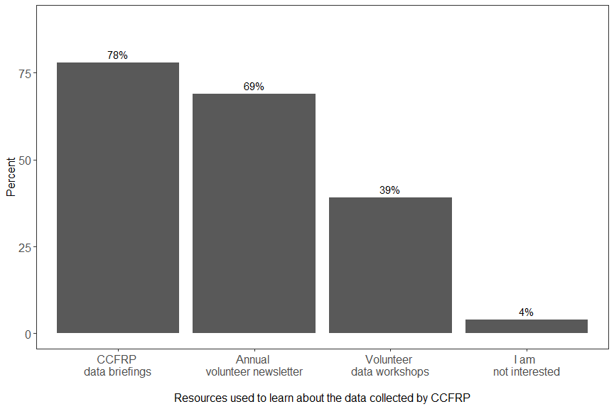

```r
ss7
```

### **QUESTION 8**

```r
yesno <- c("Yes", "No")

ss8 <- survey_dat_clean %>% select(q8) %>% drop_na() %>% count(q8 = factor(q8))%>%
    mutate(pct = n/sum(n)*100,
           pct = round(pct, digits = 0))%>%
  ggplot(aes(x = q8, y = pct, label = paste0(pct, "%")))+
  geom_col(position = "dodge")+
  geom_text(position = position_dodge(width = 0.9),
            vjust = -0.5,
            size = 4)+
  scale_y_continuous(limits = c(0,100)) +
  scale_x_discrete(labels = yesno) +
  labs(x = '\nI have told my recreational fishing buddies about CCFRP', y = 'Percent') +
  theme_bw() +
  theme(panel.grid = element_blank(),
        legend.position = "none",
        axis.title=element_text(size=12),
        axis.text = element_text(size = 12))
```

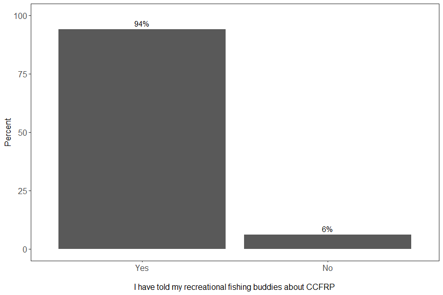

```r
ss8
```

### **MARINE PROTECTED AREAS: QUESTIONS 9 & 11**

Before and after volunteering with CCFRP, what was your general opinion of the creation of MPAs in California?

```r
beforeafter <- c('Positive', 'Somewhat \npositive', 'Neutral', 'Somewhat \nnegative', 'Negative', 'No opinion')

ss9 <- survey_dat_clean %>% select(q9) %>% drop_na() %>% count(q9 = factor(q9))%>%
    mutate(pct = n/sum(n)*100,
           pct = round(pct, digits = 0))%>%
  ggplot(aes(x = q9, y = pct, label = paste0(pct, "%")))+
  geom_col(position = "dodge")+
  #, aes(fill = Q9, color = Q9)
  #scale_color_manual(values = c("#336633", "#336633", "#FFCC99", "#CC0000", "#CC0000", "#666666"))+
  #scale_fill_manual(values = c("#336633", "#336633", "#FFCC99", "#CC0000", "#CC0000", "#666666"))+
  geom_text(position = position_dodge(width = 0.9),
            vjust = -0.5,
            size = 4)+
  scale_y_continuous(limits = c(0,75)) +
  scale_x_discrete(labels = beforeafter) +
  labs(x = '\nBefore Volunteering with CCFRP', y = 'Percent') +
  theme_bw() +
  theme(panel.grid = element_blank(),
        legend.position = "none",
        axis.title=element_text(size=12),
        axis.text = element_text(size = 12))

ss11 <- survey_dat_clean %>% select(q11) %>% drop_na() %>% count(q11 = factor(q11))%>%
    mutate(pct = n/sum(n)*100,
           pct = round(pct, digits = 0))%>%
  ggplot(aes(x = q11, y = pct, label = paste0(pct, "%")))+
  geom_col(position = "dodge")+
  # , aes(fill = q11, color = q11)
  # scale_color_manual(values = c("#336633", "#336633", "#FFCC99", "#CC0000", "#CC0000", "#666666"))+
  # scale_fill_manual(values = c("#336633", "#336633", "#FFCC99", "#CC0000", "#CC0000", "#666666"))+
  geom_text(position = position_dodge(width = 0.9),
            vjust = -0.5,
            size = 4)+
  scale_y_continuous(limits = c(0,75)) +
  scale_x_discrete(labels = beforeafter) +
  labs(x = '\nAfter Volunteering with CCFRP', y = 'Percent') +
  theme_bw() +
  theme(panel.grid = element_blank(),
        #legend.position = "none",
        axis.title=element_text(size=12),
        axis.text = element_text(size = 12))
```

```r
beforeafter <- c('Positive', 'Somewhat \npositive', 'Neutral', 'Somewhat \nnegative', 'Negative', 'No opinion')

ss9 <- survey_dat_clean %>% select(q9) %>% drop_na() %>% count(q9 = factor(q9))%>%
    mutate(pct9 = n/sum(n)*100,
           pct9 = round(pct9, digits = 0))

ss11 = survey_dat_clean %>% select(q11) %>% drop_na() %>% count(q11 = factor(q11)) %>%
    mutate(pct11 = n/sum(n)*100,
           pct11 = round(pct11, digits = 0))

ss911df = data.frame(ss9$q9, ss9$pct9, ss11$q11, ss11$pct11) %>% pivot_longer(cols=c('ss9.pct9', 'ss11.pct11'), names_to='question', values_to="pct") %>% mutate(question=as.factor(question),ss9.q9 = as.factor(ss9.q9)) %>% select(-ss11.q11) %>% rename(type = ss9.q9) %>% mutate(question = recode(question, ss9.pct9 = "before", ss11.pct11 = "after"))

ss911graph <- ss911df %>%
  mutate(question = factor(question, levels = c("before", "after"))) %>%
  ggplot(aes(x = type, fill = question, y = pct, label = paste0(pct, "%")))+
  geom_col(position = "dodge")+
  # , aes(fill = q11, color = q11)
  # scale_color_manual(values = c("#336633", "#336633", "#FFCC99", "#CC0000", "#CC0000", "#666666"))+
  # scale_fill_manual(values = c("#336633", "#336633", "#FFCC99", "#CC0000", "#CC0000", "#666666"))+
  geom_text(position = position_dodge(width = 0.9),
            vjust = -0.5,
            size = 4)+
  scale_y_continuous(limits = c(0,75)) +
  scale_x_discrete(labels = beforeafter) +
  labs(x = '', y = 'Percent') +
  theme_bw() +
  ggtitle("Opinion about MPAs before and after volunteering with CCFRP") +
  theme(panel.grid = element_blank(),
        legend.title = element_blank(),
        plot.title = element_text(hjust = 0.5),
        axis.title=element_text(size=12),
        axis.text = element_text(size = 12))
```

```r
ss9/ss11
```

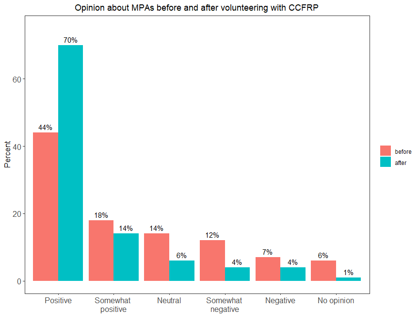

```r
ss911graph
```

### **9 and 11 diference**

```r
ss9fac <- survey_dat_clean %>% select(q9) %>% drop_na() %>% count(q11 = factor(q9))%>%
    mutate(pct = n/sum(n)*100,
           pct = round(pct, digits = 0))
ss11fac <- survey_dat_clean %>% select(q11) %>% drop_na() %>% count(q11 = factor(q11))%>%
    mutate(pct = n/sum(n)*100,
           pct = round(pct, digits = 0))
ss911fact = (ss11fac$pct - ss9fac$pct)
as.data.frame(ss911fact)
```

```
##   ss911fact
## 1        26
## 2        -4
## 3        -8
## 4        -8
## 5        -3
## 6        -5
```

```r
dfnew = ss11fac %>% add_column(change = ss911fact)

ss911change <- dfnew %>%
  ggplot(aes(x = q11, y = change, label = paste0(change, "%")))+
  geom_col(position = "dodge")+
  # , aes(fill = q11, color = q11)
  # scale_color_manual(values = c("#336633", "#336633", "#FFCC99", "#CC0000", "#CC0000", "#666666"))+
  # scale_fill_manual(values = c("#336633", "#336633", "#FFCC99", "#CC0000", "#CC0000", "#666666"))+
  geom_text(aes(y = change + 2 * sign(change)), position = position_dodge(width = 0.9),
            size = 4) +
  scale_y_continuous(limits = c(-30,30)) +
  scale_x_discrete(labels = beforeafter) +
  labs(y = 'Percent', x ="") +
  ggtitle("Percent change in opinion after volunteering with CCFRP") +
  theme_bw() +
  theme(panel.grid = element_blank(),
        plot.title = element_text(hjust = 0.5),
        #legend.position = "none",
        axis.title=element_text(size=12),
        axis.text = element_text(size = 12))
```

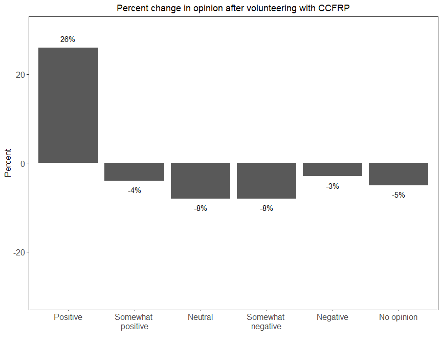

```r
ss911change
```

### **QUESTION 10 & 12**

This is a ‘select all that apply’ questions

```r
ss10_dat <- survey_dat_clean %>%
  select(q10) %>%
  separate_rows(q10)%>%
  count(q10) %>%
  mutate(pct = n/length(survey_dat_clean$q10)*100,
         pct = round(pct, digits = 1))

length(survey_dat_clean$q10)

beforeafter_groundfish <- c("Increase \nSize", "Increase \nAbundance", "Decrease \nSize",
                            "Decrease \nAbundance", "No Effect \nSize",
                            "No Effect \nAbundance", "I don\'t know", "No Opinion")

ba_groundfish_rev <- c("No Opinion", "I don\'t know", "No Effect \nAbundance", "No Effect \nSize", "Decrease \nAbundance", "Decrease \nSize", "Increase \nAbundance","Increase \nSize")


ss10 <- survey_dat_clean %>%
  select(q10) %>%
  drop_na() %>%
  separate_rows(q10) %>%
  count(q10 = factor(q10))%>%
  mutate(pct = n/sum(!is.na(survey_dat_clean$q10))*100,
         pct = round(pct, digits = 1))%>%
  ggplot(aes(x = q10, y = pct, label = paste0(pct, "%")))+
  geom_col(position = "dodge")+
  geom_text(position = position_dodge(width = 0.9),
            vjust = -0.5,
            size = 4)+
  scale_y_continuous(limits = c(0,90)) +
  scale_x_discrete(labels = beforeafter_groundfish) +
  #coord_flip()+
  labs(x = '\nDo MPAs affect size/abundance of groundfish? \nBefore Volunteering', y = 'Percent') +
  theme_bw() +
  theme(panel.grid = element_blank(),
        legend.position = "none",
        axis.title=element_text(size=12),
        axis.text = element_text(size = 12))
```

```r
ss10
```

[output not shown]

```r
ss12 <- survey_dat_clean %>%
  select(q12) %>%
  drop_na() %>%
  separate_rows(q12) %>%
  count(q12 = factor(q12))%>%
  mutate(pct = n/sum(!is.na(survey_dat_clean$q12))*100,
         pct = round(pct, digits = 1))%>%
  ggplot(aes(x = q12, y = pct, label = paste0(pct, "%")))+
  geom_col(position = "dodge")+
  geom_text(position = position_dodge(width = 0.9),
            vjust = 0.0,
            hjust = -0.6,
            size = 4)+
  scale_y_continuous(limits = c(0,100)) +
  scale_x_discrete(limits= rev, labels = ba_groundfish_rev) +
  coord_flip() +
  labs(x = '\nDo MPAs affect groundifhs size/abundance? \n After Volunteering\n', y = 'Percent') +
  theme_bw() +
  theme(panel.grid = element_blank(),
        legend.position = "none",
        axis.title=element_text(size=12),
        axis.text = element_text(size = 12))
```

```r
ss12
```

[output not shown]

### **Question 10 and 12**

```r
beforeafter <- c('Positive', 'Somewhat \npositive', 'Neutral', 'Somewhat \nnegative', 'Negative', 'No opinion')

ss10 <- survey_dat_clean %>%
  select(q10) %>%
  drop_na() %>%
  separate_rows(q10) %>%
  count(q10 = factor(q10))%>%
  mutate(pct10 = n/sum(!is.na(survey_dat_clean$q10))*100,
         pct10 = round(pct10, digits = 1))


ss12 <- survey_dat_clean %>%
  select(q12) %>%
  drop_na() %>%
  separate_rows(q12) %>%
  count(q12 = factor(q12))%>%
  mutate(pct12 = n/sum(!is.na(survey_dat_clean$q12))*100,
         pct12 = round(pct12, digits = 1))

ss1012df = data.frame(ss10$q10, ss10$pct10, ss12$q12, ss12$pct12) %>% pivot_longer(cols=c('ss10.pct10', 'ss12.pct12'), names_to='question', values_to="pct") %>% mutate(question=as.factor(question),ss10.q10 = as.factor(ss10.q10)) %>% select(-ss12.q12) %>% rename(type = ss10.q10) %>% mutate(question = recode(question, ss10.pct10 = "before", ss12.pct12 = "after"))

beforeafter_groundfish <- c("Increase \nSize", "Increase \nAbundance", "Decrease \nSize",
                            "Decrease \nAbundance", "No Effect \nSize",
                            "No Effect \nAbundance", "I don\'t know", "No Opinion")

ba_groundfish_rev <- c("No Opinion", "I don\'t know", "No Effect \nAbundance", "No Effect \nSize", "Decrease \nAbundance", "Decrease \nSize", "Increase \nAbundance","Increase \nSize")

ss1012graph <- ss1012df %>%
  mutate(question = factor(question, levels = c("before", "after"))) %>%
  ggplot(aes(x = type, fill = question, y = pct, label = paste0(pct, "%")))+
  geom_col(position = "dodge")+
  geom_text(position = position_dodge(width = 0.9),
            vjust = 0.0,
            hjust = -0.6,
            size = 4) +
  scale_y_continuous(limits = c(0,100)) +
  scale_x_discrete(limits= rev, labels = ba_groundfish_rev) +
  coord_flip() +
  labs(x = '\nDo MPAs affect groundifhs size/abundance \n After Volunteering\n?', y = 'Percent') +
  theme_bw() +
  theme(panel.grid = element_blank(),
        #legend.position = "none",
        axis.title=element_text(size=12),
        legend.title = element_blank(),
        axis.text = element_text(size = 12))
```

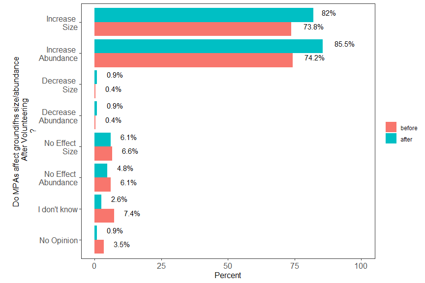

```r
ss1012graph
```

### **10 and 12 diference**

```r
ss10fac <- survey_dat_clean %>%
  select(q10) %>%
  drop_na() %>%
  separate_rows(q10) %>%
  count(q10 = factor(q10))%>%
  mutate(pct10 = n/sum(!is.na(survey_dat_clean$q10))*100,
         pct10 = round(pct10, digits = 1))


ss12fac <- survey_dat_clean %>%
  select(q12) %>%
  drop_na() %>%
  separate_rows(q12) %>%
  count(q12 = factor(q12))%>%
  mutate(pct12 = n/sum(!is.na(survey_dat_clean$q12))*100,
         pct12 = round(pct12, digits = 1))

ss1012fac = (ss12fac$pct12 - ss10fac$pct10)
as.data.frame(ss1012fac)
```

```
##   ss1012fac
## 1       8.2
## 2      11.3
## 3       0.5
## 4       0.5
## 5      -0.5
## 6      -1.3
## 7      -4.8
## 8      -2.6
```

```r
dfnew = ss12fac %>% add_column(change = ss1012fac)


beforeafter_groundfish <- c("Increase \nSize", "Increase \nAbundance", "Decrease \nSize",
                            "Decrease \nAbundance", "No Effect \nSize",
                            "No Effect \nAbundance", "I don\'t know", "No Opinion")

ba_groundfish_rev <- c("No Opinion", "I don\'t know", "No Effect \nAbundance", "No Effect \nSize", "Decrease \nAbundance", "Decrease \nSize", "Increase \nAbundance","Increase \nSize")

ss1012change <- dfnew %>%
  ggplot(aes(x = q12, y = change, label = paste0(change, "%")))+
  geom_col(position = "dodge")+
  # , aes(fill = q11, color = q11)
  # scale_color_manual(values = c("#336633", "#336633", "#FFCC99", "#CC0000", "#CC0000", "#666666"))+
  # scale_fill_manual(values = c("#336633", "#336633", "#FFCC99", "#CC0000", "#CC0000", "#666666"))+
  geom_text(aes(y = change + 2 * sign(change)), position = position_dodge(width = 0.9),
            size = 4) +
  scale_y_continuous(limits = c(-15,15)) +
 scale_x_discrete(limits= rev, labels = ba_groundfish_rev)+
  labs(y = 'Percent', x ="") +
  ggtitle("Percent change in opinion after volunteering with CCFRP") +
  theme_bw() +
  theme(panel.grid = element_blank(),
        plot.title = element_text(hjust = 0.5),
        #legend.position = "none",
        axis.title=element_text(size=12),
        axis.text = element_text(size = 12))
```

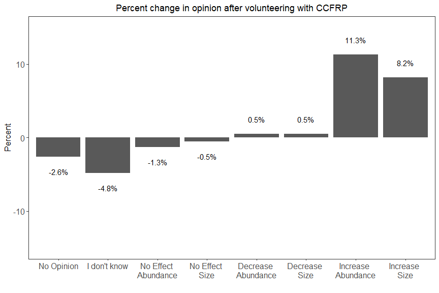

```r
ss1012change
```

### **QUESTION 13**

```r
mpa_aspects <- c("Location", "Size", "Enforcement", "Network", "Fish population \nprotection", "Voluntary \ncompliance", "Other", "I do not \nbelieve there \nis an effect")

ss13 <- survey_dat_clean %>%
  select(q13) %>%
  drop_na() %>%
  separate_rows(q13) %>%
  count(q13 = factor(q13))%>%
  mutate(pct = n/sum(!is.na(survey_dat_clean$q13))*100,
         pct = round(pct, digits = 0))%>%
  ggplot(aes(x = q13, y = pct, label = paste0(pct, "%")))+
  geom_col(position = "dodge")+
  geom_text(position = position_dodge(width = 0.9),
            vjust = -0.5,
            size = 4)+
  scale_y_continuous(limits = c(0,90)) +
  scale_x_discrete(labels = mpa_aspects) +
  labs(x = '\nWhat aspects of MPAs affected groundfish size/abundance?', y = 'Percent') +
  theme_bw() +
  theme(panel.grid = element_blank(),
        legend.position = "none",
        axis.title=element_text(size=12),
        axis.text = element_text(size = 12))
```

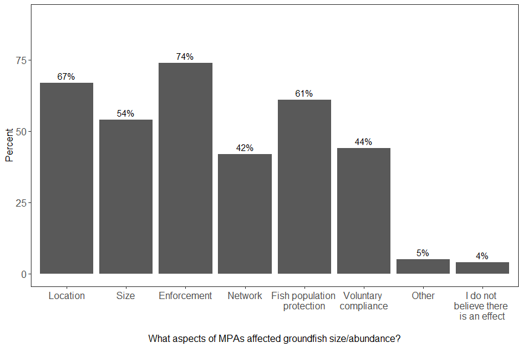

```r
ss13
```

### **QUESTION 14**

```r
mpa_purpose <- c("Conserve, restore, \nand understand \nnatural biodiversity \nand ecology", "Provide opportunity \nto experience \nthese areas ", "Restrict industrial \nuses", "Prevent overfishing\n/overuse/degredation", "No purpose", "No opinion")

ss14 <- survey_dat_clean %>%
  select(q14) %>%
  drop_na() %>%
  separate_rows(q14) %>%
  count(q14 = factor(q14))%>%
  mutate(pct = n/sum(!is.na(survey_dat_clean$q14))*100,
         pct = round(pct, digits = 1))%>%
  ggplot(aes(x = q14, y = pct, label = paste0(pct, "%")))+
  geom_col(position = "dodge")+
  geom_text(position = position_dodge(width = 0.9),
            vjust = -0.5,
            size = 4)+
  scale_y_continuous(limits = c(0,90)) +
  scale_x_discrete(labels = mpa_purpose) +
  labs(x = '\nWhat is the purpose of an MPA?', y = 'Percent') +
  theme_bw() +
  theme(panel.grid = element_blank(),
        legend.position = "none",
        axis.title=element_text(size=12),
        axis.text = element_text(size = 11))
```

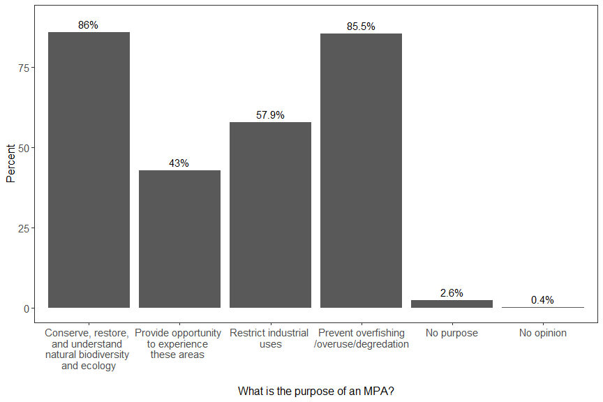

```r
ss14
```

### **QUESTION 15**

```r
yesno <- c("Yes", "No")

ss15 <- survey_dat_clean %>% select(q15) %>% drop_na() %>% count(q15 = factor(q15))%>%
    mutate(pct = n/sum(n)*100,
           pct = round(pct, digits = 0))%>%
  ggplot(aes(x = q15, y = pct, label = paste0(pct, "%")))+
  geom_col(position = "dodge")+
  geom_text(position = position_dodge(width = 0.9),
            vjust = -0.5,
            size = 4)+
  scale_y_continuous(limits = c(0,75)) +
  scale_x_discrete(labels = yesno) +
  labs(x = 'Have You Fished in an MPA?', y = 'Percent') +
  theme_bw() +
  theme(panel.grid = element_blank(),
        legend.position = "none",
        axis.title=element_text(size=12),
        axis.text = element_text(size = 12))
```

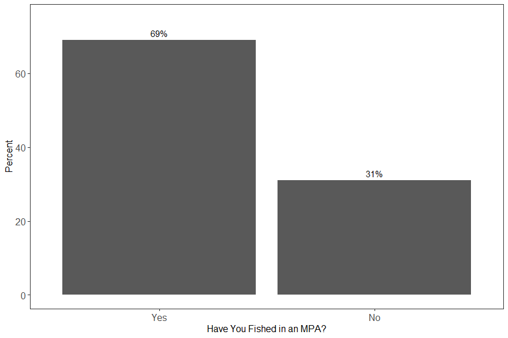

```r
ss15
```

### **GENERAL: QUESTIONS 16 a-c**

Have you experienced a difference in fishing in an MPA versus outside of an MPA?

- I catch more fish when fishing inside…
- I catch a greater diversity of fish species when fishing inside…
- I catch larger fish when I fish inside…

```r
## answer option list
fishingarea <- c('MPAs', 'Open to Fishing', 'Don\'t Know', 'No Difference')

ss16a <- survey_dat_clean %>% select(q16) %>% drop_na() %>% count(q16 = factor(q16))%>%
    mutate(pct = n/sum(n)*100,
           pct = round(pct, digits = 0))%>%
  ggplot(aes(x = q16, y = pct, label = paste0(pct, "%")))+
  geom_col(position = "dodge")+
  geom_text(position = position_dodge(width = 0.9),
            vjust = -0.5,
            size = 4)+
  scale_y_continuous(limits = c(0,85)) +
  scale_x_discrete(labels = fishingarea) +
  labs(x = '\nHigher Abundance', y = '\nPercent') +
  theme_bw() +
  theme(panel.grid = element_blank(),
        legend.position = "none",
        axis.title=element_text(size=12),
        axis.text = element_text(size = 12))

ss16b <- survey_dat_clean %>% select(q17) %>% drop_na() %>% count(q17 = factor(q17))%>%
    mutate(pct = n/sum(n)*100,
           pct = round(pct, digits = 0))%>%
  ggplot(aes(x = q17, y = pct, label = paste0(pct, "%")))+
  geom_col(position = "dodge")+
  geom_text(position = position_dodge(width = 0.9),
            vjust = -0.5,
            size = 4)+
  scale_y_continuous(limits = c(0,85)) +
  scale_x_discrete(labels = fishingarea) +
  labs(x = '\nGreater Diversity', y = '\nPercent') +
  theme_bw() +
  theme(panel.grid = element_blank(),
        legend.position = "none",
        axis.title=element_text(size=12),
        axis.text = element_text(size = 12))

ss16c <- survey_dat_clean %>% select(q18) %>% drop_na() %>% count(q18 = factor(q18))%>%
    mutate(pct = n/sum(n)*100,
           pct = round(pct, digits = 0))%>%
  ggplot(aes(x = q18, y = pct, label = paste0(pct, "%")))+
  geom_col(position = "dodge")+
  geom_text(position = position_dodge(width = 0.9),
            vjust = -0.5,
            size = 4)+
  scale_y_continuous(limits = c(0,85)) +
  scale_x_discrete(labels = fishingarea) +
  labs(x = '\nLarger Size', y = '\nPercent') +
  theme_bw() +
  theme(panel.grid = element_blank(),
        legend.position = "none",
        axis.title=element_text(size=12),
        axis.text = element_text(size = 12))
```

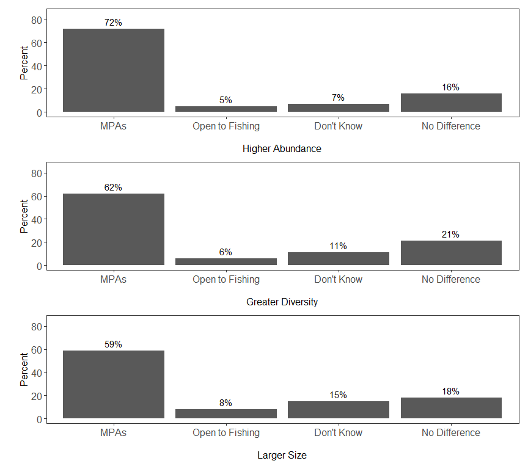

```r
ss16a/ss16b/ss16c
```

### **QUESTION 17**

```r
prime_reason <- c("No preference \nfor MPA", "Larger Fish", "More Fish", "More Species", "Collect Scientific \nFishing Data")
## question 17 is q19

ss17 <- survey_dat_clean %>% select(q19) %>% drop_na() %>% count(q19 = factor(q19))%>%
    mutate(pct = n/sum(n)*100,
           pct = round(pct, digits = 0))%>%
  ggplot(aes(x = q19, y = pct, label = paste0(pct, "%")))+
  geom_col(position = "dodge")+
  geom_text(position = position_dodge(width = 0.9),
            vjust = -0.5,
            size = 4)+
  scale_y_continuous(limits = c(0,75)) +
  scale_x_discrete(labels = prime_reason) +
  labs(x = '\nWhat is the primary reason you enjoy MPA fishing with CCFRP?', y = 'Percent') +
  theme_bw() +
  theme(panel.grid = element_blank(),
        legend.position = "none",
        axis.title=element_text(size=12),
        axis.text = element_text(size = 12))
```

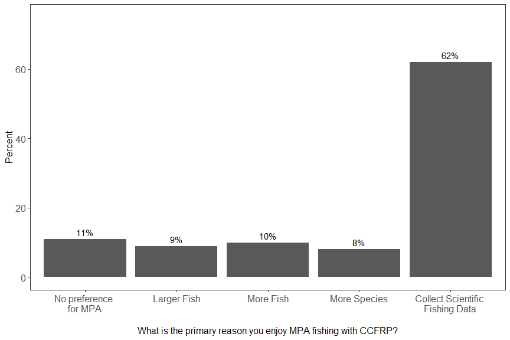

```r
ss17
```

### **QUESTION 18**

Hypothetically, how much would you be willing to pay for one day of catch and release fishing inside an MPA while not participating on a CCFRP trip?

```r
money <- c('$0', '$1 - $20', '$21 - $50', '$51 - 100', '$101 - $500', '>$500')

ss18 <- survey_dat_clean %>% select(q20) %>% drop_na() %>% count(q20 = factor(q20))%>%
    mutate(pct = n/sum(n)*100,
           pct = round(pct, digits = 0))%>%
  ggplot(aes(x = q20, y = pct, label = paste0(pct, "%")))+
  geom_col(position = "dodge")+
  geom_text(position = position_dodge(width = 0.9),
            vjust = -0.5,
            size = 4)+
  scale_y_continuous(limits = c(0,50)) +
  scale_x_discrete(labels = money) +
  labs(x = '\nHow Much Would You Pay to Fish in an MPA?', y = '\nPercent') +
  theme_bw() +
  theme(panel.grid = element_blank(),
        legend.position = "none",
        axis.title=element_text(size=12),
        axis.text = element_text(size = 12))
```

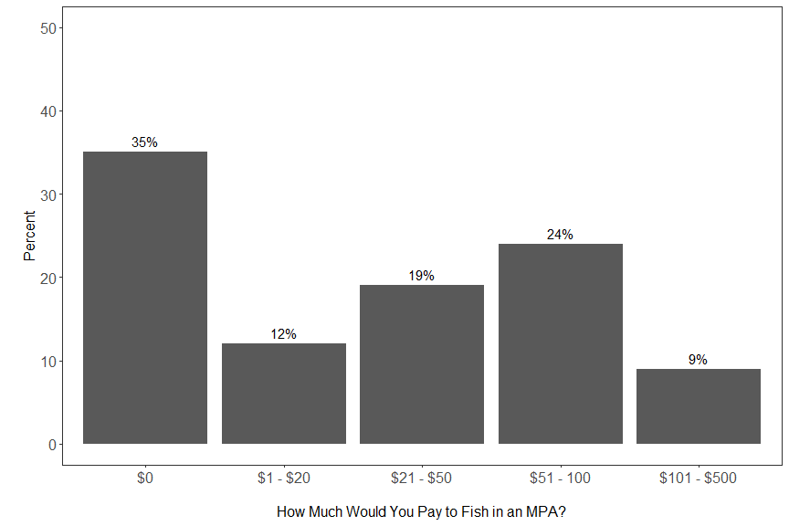

```r
ss18
```

### **NATURAL RESOURCE CONSERVATION: QUESTION 19**

```r
moreless <- c("More", "Less", "Similar", "I don\'t know")
## question 19 is q22

ss19 <- survey_dat_clean %>% select(q22) %>% drop_na() %>% count(q22 = factor(q22))%>%
    mutate(pct = n/sum(n)*100,
           pct = round(pct, digits = 0))%>%
  ggplot(aes(x = q22, y = pct, label = paste0(pct, "%")))+
  geom_col(position = "dodge")+
  geom_text(position = position_dodge(width = 0.9),
            vjust = -0.5,
            size = 4)+
  scale_y_continuous(limits = c(0,75)) +
  scale_x_discrete(labels = moreless) +
  labs(x = '\nAre you more or less conservation-minded than others?', y = 'Percent') +
  theme_bw() +
  theme(panel.grid = element_blank(),
        legend.position = "none",
        axis.title=element_text(size=12),
        axis.text = element_text(size = 12))
```

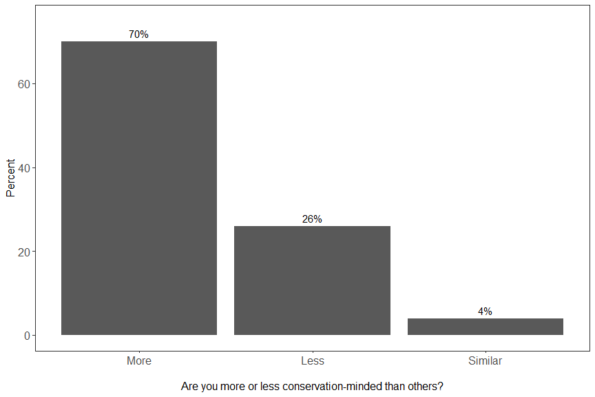

```r
ss19
```

### **QUESTION 20**

```r
## question 20 is q23

ss20 <- survey_dat_clean %>% select(q23) %>% drop_na() %>% count(q23 = factor(q23))%>%
    mutate(pct = n/sum(n)*100,
           pct = round(pct, digits = 0))%>%
  ggplot(aes(x = q23, y = pct, label = paste0(pct, "%")))+
  geom_col(position = "dodge")+
  geom_text(position = position_dodge(width = 0.9),
            vjust = -0.5,
            size = 4)+
  scale_y_continuous(limits = c(0,75)) +
  scale_x_discrete(labels = yesno) +
  labs(x = '\nDo you participate with other conservation-oriented groups?', y = 'Percent') +
  theme_bw() +
  theme(panel.grid = element_blank(),
        legend.position = "none",
        axis.title=element_text(size=12),
        axis.text = element_text(size = 12))
```

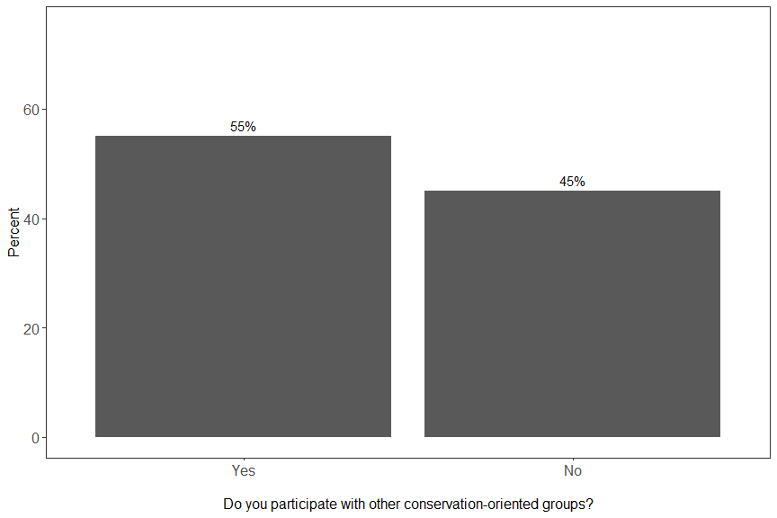

```r
ss20
```

### **QUESTION 21**

```r
inform = c("Not well", "Somewhat", "Well", "Very Well", "Unsure")

ss21 <- survey_dat_clean %>% select(q24) %>% drop_na() %>% count(q24 = factor(q24))%>%
    mutate(pct = n/sum(n)*100,
           pct = round(pct, digits = 0))%>%
  ggplot(aes(x = q24, y = pct, label = paste0(pct, "%")))+
  geom_col(position = "dodge")+
  geom_text(position = position_dodge(width = 0.9),
            vjust = -0.5,
            size = 4)+
  scale_y_continuous(limits = c(0,45)) +
  scale_x_discrete(labels = inform) +
  labs(x = '\nHow informed do you consider yourself to be concerning ocean issues in Califronia?', y = 'Percent') +
  theme_bw() +
  theme(panel.grid = element_blank(),
        legend.position = "none",
        axis.title=element_text(size=12),
        axis.text = element_text(size = 12))
```

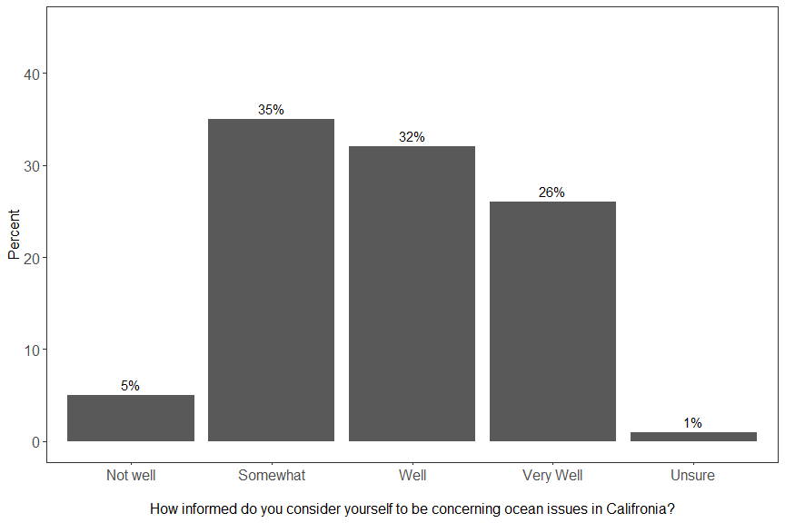

```r
ss21
```

### **QUESTION 22**

**1 = “CCFRP related events (Volunteer Appreciation/ Data Workshops)”**

**2 = “Newspaper”**

**3 = “Magazine”**

**4 = “Family/Friends”**

**5 = “Radio”**

**6 = “Internet”**

**7 = “Social Media”**

**8 = “Television”**

**9 = “Other”**

**10 = “I have not sought out information on ocean related issues”**

```r
## Question 22 is q25
info <- c("CCFRP \nrelated events", "Newspaper", "Magazine", "Family\n/friends", "Radio", "Internet", "Social \nmedia", "Television", "Other", "I have not \nsought out \ninformation on \nocean-related \nissues")

ss22 <- survey_dat_clean %>%
  select(q25) %>%
  drop_na() %>%
  separate_rows(q25) %>%
  count(q25 = factor(q25))%>%
  mutate(pct = n/sum(!is.na(survey_dat_clean$q25))*100,
         pct = round(pct, digits = 1))%>%
  ggplot(aes(x = q25, y = pct, label = paste0(pct, "%")))+
  geom_col(position = "dodge")+
  geom_text(position = position_dodge(width = 0.9),
            vjust = -0.5,
            size = 4)+
  scale_y_continuous(limits = c(0,90)) +
  scale_x_discrete(labels = info) +
  labs(x = '\nWhere do you obtain information about ocean-related issues?', y = 'Percent') +
  theme_bw() +
  theme(panel.grid = element_blank(),
        legend.position = "none",
        axis.title=element_text(size=12),
        axis.text = element_text(size = 11))
```

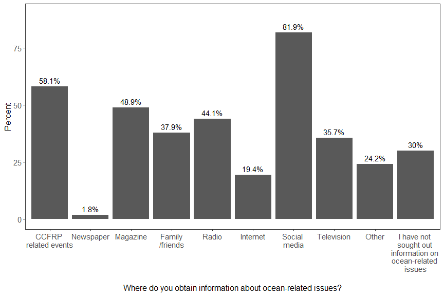

```r
ss22
```

### **QUESTION 23**

In your opinion, how well are California groundfish stocks managed?

```r
## question 23 is q26
managed <- c('Very Well', 'Well', 'Adequately', 'Poorly', 'Very Poorly', 'Not Managed', 'Don\'t Know')

ss23 <- survey_dat_clean %>% select(q26) %>% drop_na() %>% count(q26 = factor(q26))%>%
    mutate(pct = n/sum(n)*100,
           pct = round(pct, digits = 0))%>%
  ggplot(aes(x = q26, y = pct, label = paste0(pct, "%")))+
  geom_col(position = "dodge")+
  geom_text(position = position_dodge(width = 0.9),
            vjust = -0.5,
            size = 4)+
  scale_y_continuous(limits = c(0,50)) +
  scale_x_discrete(labels = managed) +
  labs(x = '\nHow Well Managed are California Fisheries?', y = '\nPercent') +
  theme_bw() +
  theme(panel.grid = element_blank(),
        legend.position = "none",
        axis.title=element_text(size=12),
        axis.text = element_text(size = 12))
```

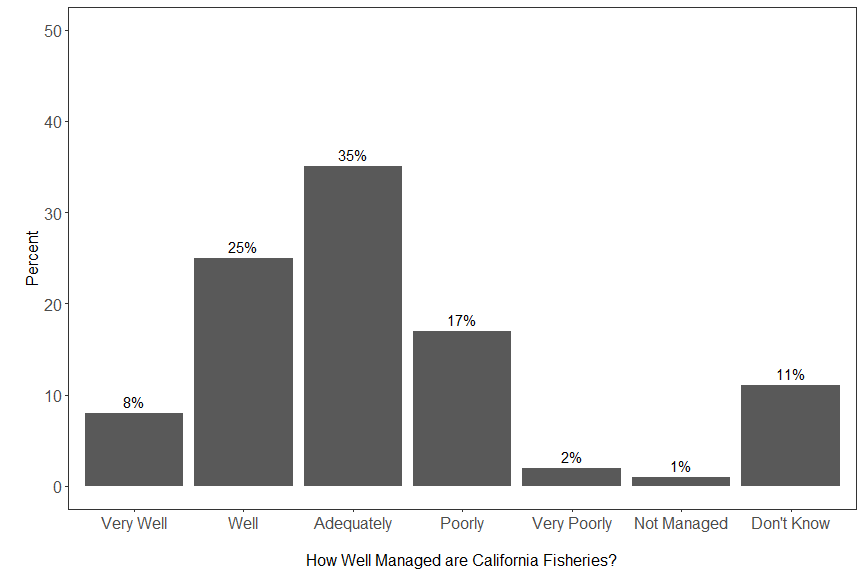

```r
ss23
```

Time Volunteered Breakdown

Region Breakdown

### **QUESTION 24**

```r
# gear <- c("Traps or pots", "Hook & line, \nrecreational", "Bottom \ntrawling",
#           "Longline", "Gill nets", "Midwater \ntrawling",
#           "Hook & line, \ncommercial", "Spearfishing")

ss24 <- survey_dat_clean%>%
  select(q27_1:q27_8) %>%
  pivot_longer(cols = q27_1:q27_8, names_to = "gear_type") %>%
  mutate(value = as.numeric(value))%>%
  group_by(gear_type)%>%
  summarize(mean = mean(value, na.rm = T),
            mean = round(mean, digits = 2),
            mean_lbl = format(round(mean, digits = 2), nsmall = 2),
            se = std.error(value),
            sd = sd(value, na.rm = T)) %>%
  mutate(gearname = case_when(
    gear_type == "q27_1" ~ "Traps \nor pots",
    gear_type == "q27_2" ~ "Hook & line, \nrecreational",
    gear_type == "q27_3" ~ "Bottom \ntrawling",
    gear_type == "q27_4" ~ "Longline",
    gear_type == "q27_5" ~ "Gill nets",
    gear_type == "q27_6" ~ "Midwater \ntrawling",
    gear_type == "q27_7" ~ "Hook & line, \ncommercial",
    gear_type == "q27_8" ~ "Spearfishing",
  )) %>%
  ggplot(aes(x = reorder(gearname, -mean, sum),
                           y = mean, label = mean_lbl))+
  geom_col(position = "dodge")+
  geom_text(position = position_dodge2(width = 0.9),
            vjust = 0.0,
            hjust = -1.2,
            size = 4)+
  geom_errorbar(aes(ymin = mean - se, ymax = mean + se), width = 0.2)+
  scale_y_continuous(limits = c(0, 8), breaks = c(0:8))+
  scale_x_discrete(limits = rev)+
  labs(x = "Gear Type \n", y = "Mean Impact Score")+
  coord_flip()+
  theme_bw()+
  theme(panel.grid = element_blank(),
        legend.position = "none",
        axis.title = element_text(size = 12),
        axis.text = element_text(size = 12))
```

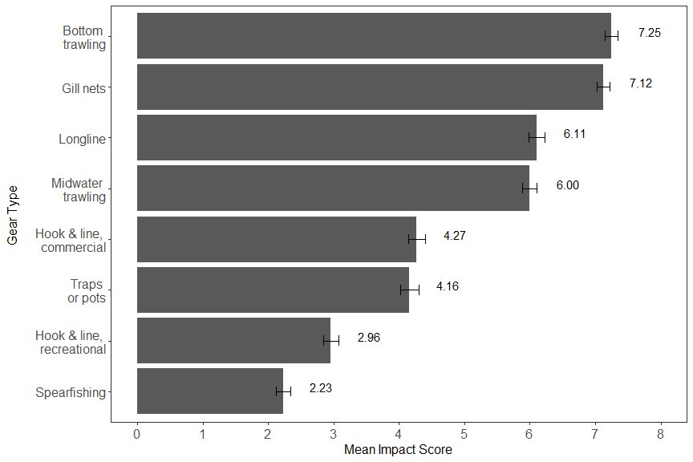

```r
ss24
```

### **QUESTION 25**

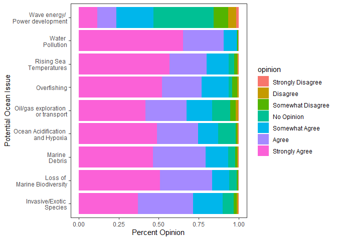

```r
ss25 <- survey_dat_clean %>%
  select(q28_1:q28_9) %>%
  pivot_longer(cols = q28_1:q28_9, names_to = "oc_issue") %>%
  mutate(value = as.numeric(value),
         ocean_issue = case_when(
    oc_issue == "q28_1" ~ "Water \nPollution",
    oc_issue == "q28_2" ~ "Marine \nDebris",
    oc_issue == "q28_3" ~ "Loss of \nMarine Biodiversity",
    oc_issue == "q28_4" ~ "Overfishing",
    oc_issue == "q28_5" ~ "Invasive/Exotic \nSpecies",
    oc_issue == "q28_6" ~ "Rising Sea \nTemperatures",
    oc_issue == "q28_7" ~ "Ocean Acidification \nand Hypoxia",
    oc_issue == "q28_8" ~ "Wave energy/ \nPower development",
    oc_issue == "q28_9" ~ "Oil/gas exploration \nor transport"),
    opinion = case_when(
      value == 1 ~ "Strongly Disagree",
      value == 2 ~ "Disagree",
      value == 3 ~ "Somewhat Disagree",
      value == 4 ~ "No Opinion",
      value == 5 ~ "Somewhat Agree",
      value == 6 ~ "Agree",
      value == 7 ~ "Strongly Agree",
    )) %>%
  mutate(opinion = factor(opinion, levels = c("Strongly Disagree", "Disagree", "Somewhat Disagree", "No Opinion", "Somewhat Agree", "Agree", "Strongly Agree"))) %>%
  drop_na()

ggplot(data = ss25, aes(x = ocean_issue, y = value, fill = opinion))+
  geom_bar(position = "fill", stat = "identity")+
  labs(y = "Percent Opinion", x = "Potential Ocean Issue")+
  coord_flip()+
  theme_bw()+
  theme(panel.grid = element_blank())
```

### **QUESTION 26**

```r
f = (survey_dat_clean$q39)
survey_dat_clean$q39 = factor(survey_dat_clean$q39, levels = c(1, 2, 3, 4, 5, 6, 7))


ss26 <- survey_dat_clean %>% select(q39) %>%
  drop_na() %>%
  count(q39 = factor(q39), drop = FALSE)%>%
    mutate(pct = n/sum(n)*100,
           pct = round(pct, digits = 1), drop = FALSE)%>%
  mutate(q39=factor(q39))%>%
  ggplot(aes(x = q39, y = pct, label = paste0(pct, "%")))+
  geom_col(position = "dodge")+
  geom_text(position = position_dodge(width = 0.9),
            vjust = -0.5,
            size = 4)+
  scale_y_continuous(limits = c(0,75)) +
 scale_x_discrete(drop = FALSE, labels = c("B", "C", "D", "E", "F", "G")) +
  labs(x = 'How interconnected are you with nature?', y = 'Percent') +
  theme_bw() +
  theme(panel.grid = element_blank(),
        legend.position = "none",
        axis.title=element_text(size=12),
        axis.text = element_text(size = 12))

ss26.1 = ggdraw(ss26) +
  draw_image("vendiagram.png", scale = .5, y = .3)
```

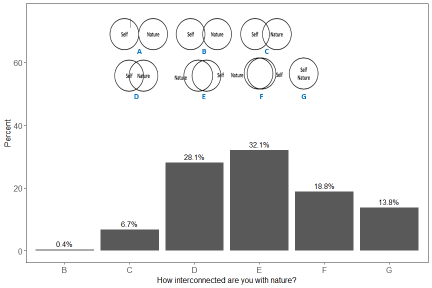

```r
ss26.1
```

### **BASIC DEMOGRAPHICS: IDENTITY (QUESTION 28)**

```r
## question 28 is q31
ss28 <- survey_dat_clean %>% select(q31) %>% drop_na() %>% count(q31 = factor(q31))%>%
    mutate(pct = n/sum(n)*100,
           pct = round(pct, digits = 0))%>%
  ggplot(aes(x = q31, y = pct, label = paste0(pct, "%")))+
  geom_col(position = "dodge")+
  geom_text(position = position_dodge(width = 0.9),
            vjust = -0.5,
            size = 4)+
  scale_y_continuous(limits = c(0,100)) +
  scale_x_discrete(labels = c('Male', 'Female', 'Non-binary', 'Prefer not to state', 'Other')) +
  labs(x = '\nGender Identity', y = '\nPercent') +
  theme_bw() +
  theme(panel.grid = element_blank(),
        legend.position = "none",
        axis.title=element_text(size=12),
        axis.text = element_text(size = 12))
```

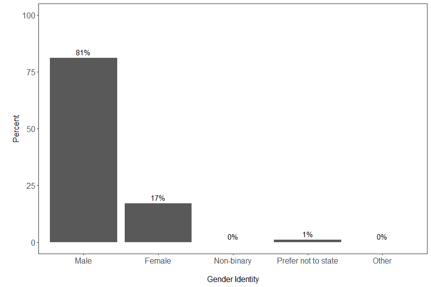

```r
ss28
```

### **BASIC DEMOGRAPHICS: AGE (QUESTION 29)**

```r
## question 29 is q32
ss29 <- survey_dat_clean %>% select(q32) %>% drop_na() %>% count(q32 = factor(q32))%>%
    mutate(pct = n/sum(n)*100,
           pct = round(pct, digits = 0))%>%
  ggplot(aes(x = q32, y = pct, label = paste0(pct, "%")))+
  geom_col(position = "dodge")+
  geom_text(position = position_dodge(width = 0.9),
            vjust = -0.5,
            size = 4)+
  scale_y_continuous(limits = c(0,40)) +
  scale_x_discrete(labels = c('18-24', '25-34', '35-44','45-54','55-64','65 and up')) +
  labs(x = '\nAge', y = '\nPercent') +
  theme_bw() +
  theme(panel.grid = element_blank(),
        legend.position = "none",
        axis.title=element_text(size=12),
        axis.text = element_text(size = 12))
```

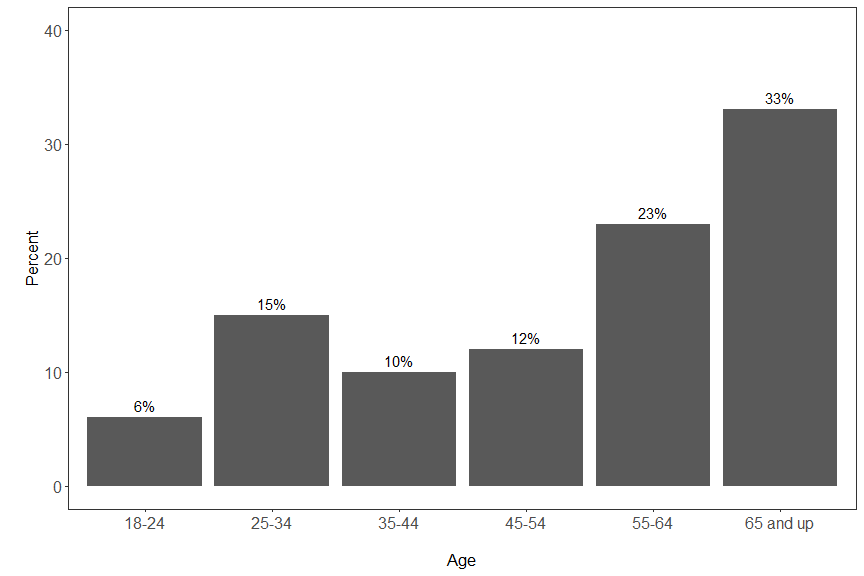

```r
ss29
```

### **BASIC DEMOGRAPHICS: EDUCATION (QUESTION 30)**

```r
## question 30 is q33

ss30 <- survey_dat_clean %>% select(q33) %>% drop_na() %>% count(q33 = factor(q33))%>%
    mutate(pct = n/sum(n)*100,
           pct = round(pct, digits = 0))%>%
  ggplot(aes(x = q33, y = pct, label = paste0(pct, "%")))+
  geom_col(position = "dodge")+
  geom_text(position = position_dodge(width = 0.9),
            vjust = -0.5,
            size = 4)+
  scale_y_continuous(limits = c(0,60)) +
  scale_x_discrete(labels = c('Less than \nhigh school degree', 'High school \ndegree', 'Associates degree \nor Tech school', 'Some college', 'College degree', 'Graduate degree')) +
  labs(x = '\nEducation', y = '\nPercent') +
  theme_bw() +
  theme(panel.grid = element_blank(),
        legend.position = "none",
        axis.title=element_text(size=12),
        axis.text = element_text(size = 12))
```

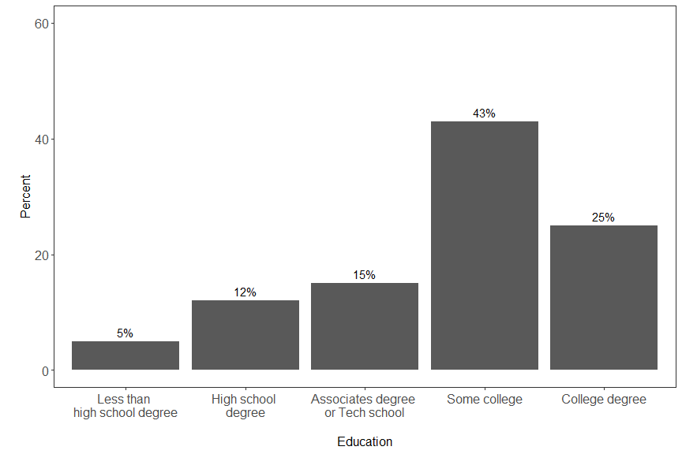

```r
ss30
```

### **BASIC DEMOGRAPHICS: SALARY (QUESTION 31)**

```r
## question 31 is q34

ss31 <- survey_dat_clean %>% select(q34) %>% drop_na() %>% count(q34 = factor(q34))%>%
    mutate(pct = n/sum(n)*100,
           pct = round(pct, digits = 0))%>%
  ggplot(aes(x = q34, y = pct, label = paste0(pct, "%")))+
  geom_col(position = "dodge")+
  geom_text(position = position_dodge(width = 0.9),
            vjust = -0.5,
            size = 4)+
  scale_y_continuous(limits = c(0,25)) +
  scale_x_discrete(labels = c('<$25k', '$25-\n$35k', '$35-\n$50k', '$50-\n$75k', '$75-\n$100k', '$100-\n$150k', '$150-\n$200k', '>$200k', 'Decline \nto State')) +
  labs(x = '\nIncome', y = '\nPercent') +
  theme_bw() +
  theme(panel.grid = element_blank(),
        legend.position = "none",
        axis.title=element_text(size=12),
        axis.text = element_text(size = 12))
```

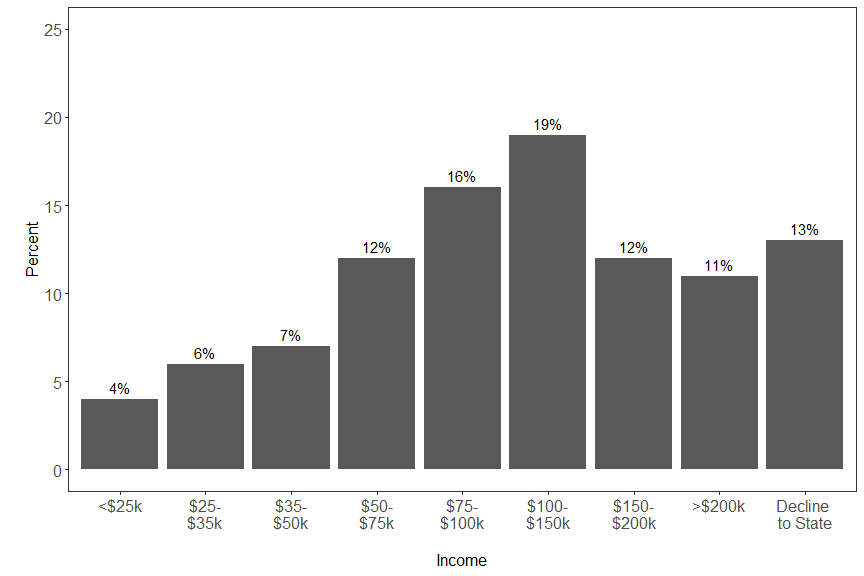

```r
ss31
```

### **QUESTION 32**

### **QUESTION 33**

### **QUESTION 34**

Go to top

# In-Depth Plots and Analyses

**GOALS/LAB MEETING NOTES (2021-09)**:

- Should we break down some of these by demographic information?
  - Education level would be interesting
  - Interconnectedness with nature (not really demographic, but still interesting)
- Breakdown by institution… or is that going to be biased because CP and MLML have been running CCFRP for longer? Maybe table this until speaking w the group again.
- Breakdown by length of volunteer time? Easy enough, subtract year column from 2021 and use those numbers as categories. Should each year be a category, or should we bin by number of years volunteered? `1-2`, `3-4`, `5-6`, `7-8`, `9-10`, `>10`?
- Alternative ways to visualize the data

## Data Prep for Vis

```r
survey_dat_an <- survey_dat_clean %>%
  select(q1:unanswered)
```

## Length of Time Volunteered

The potential hypothesis here being that the longer an angler has volunteered with CCFRP, the more their opinions will have shifted to the ‘positive’ side of viewing the creation of MPAs (questions 9 & 11), the higher their opinion of the management of California’s groundfish stocks (question 23). Potentially that volunteers who have been with CCFRP for many years will also think that fishes are more abundant, diverse, and larger within MPAs than outside of them (the ‘skip’ code in question 15 in Qualtrics should take care of those who had never fished in an MPA… otherwise this would be a caveat to consider).

### VISUALS

Breaking up some of the questions regarding feelings towards MPAs and conservaion mindedness based on the length of time that anglers have volunteered with CCFRP.

```r
time_vol_dat <- survey_dat_an %>%
  mutate(time_vol = 2021-q1 + 1) %>%
  select(q1, q9:q12, q16, q17, q18, q26, time_vol) %>%
  drop_na(time_vol, q11) %>%
  filter(q1 %in% c(2007:2021)) %>%
  mutate(time_cat = case_when(
    time_vol %in% c(1:2) ~ "1-2 years",
    time_vol %in% c(3:4) ~ "3-4 years",
    time_vol %in% c(5:6) ~ "5-6 years",
    time_vol %in% c(7:8) ~ "7-8 years",
    time_vol %in% c(9:10) ~ "9-10 years",
    time_vol > 10 ~ ">10 years",
  ))
## 5 rows of data did not have a year recorded for question 1
## 1 row did not have any 'after' information so the data would not be paired
## 3 rows not in CCFRP time frame based on angler answer (1999, 2005, 2006)


## code to check NA in data
# time_vol_dat %>%
#   select(everything())%>%
#   summarise_all(funs(sum(is.na(.))))
```

#### Questions 9 & 11 Paired Data:

```r
tv9 <- time_vol_dat %>% select(q9, time_cat) %>% drop_na() %>%
  count(q9 = factor(q9),
        time_cat = factor(time_cat, levels = c("1-2 years", "3-4 years", "5-6 years",
                                               "7-8 years", "9-10 years", ">10 years")))%>%
    mutate(pct = n/sum(n)*100,
           pct = round(pct, digits = 0))%>%
  ggplot(aes(x = q9, y = pct, label = paste0(pct, "%")))+
  geom_col(position = position_dodge2(preserve = "single"), aes(fill = time_cat))+
  scale_fill_npg()+
  scale_y_continuous(limits = c(0,30)) +
  scale_x_discrete(labels = beforeafter) +
  labs(x = '\nBefore Volunteering with CCFRP', y = 'Percent',
       fill = "Time Volunteered") +
  theme_bw() +
  theme(panel.grid = element_blank(),
        axis.title=element_text(size=12),
        axis.text = element_text(size = 12))+
  coord_flex_cart(bottom=brackets_horizontal(length=unit(0.08, 'npc')))


tv11 <- time_vol_dat %>% select(q11, time_cat) %>% drop_na() %>%
  count(q11 = factor(q11),
        time_cat = factor(time_cat, levels = c("1-2 years", "3-4 years", "5-6 years",
                                               "7-8 years", "9-10 years", ">10 years")))%>%
    mutate(pct = n/sum(n)*100,
           pct = round(pct, digits = 0))%>%
  ggplot(aes(x = q11, y = pct, label = paste0(pct, "%")))+
  geom_col(position = position_dodge2(preserve = "single"), aes(fill = time_cat))+
  scale_fill_npg()+
  scale_y_continuous(limits = c(0,30)) +
  scale_x_discrete(labels = beforeafter) +
  labs(x = '\nAfter Volunteering with CCFRP', y = 'Percent',
       fill = "Time Volunteered") +
  theme_bw() +
  theme(panel.grid = element_blank(),
        legend.position = "none",
        axis.title=element_text(size=12),
        axis.text = element_text(size = 12))+
  coord_flex_cart(bottom=brackets_horizontal(length=unit(0.08, 'npc')))
```

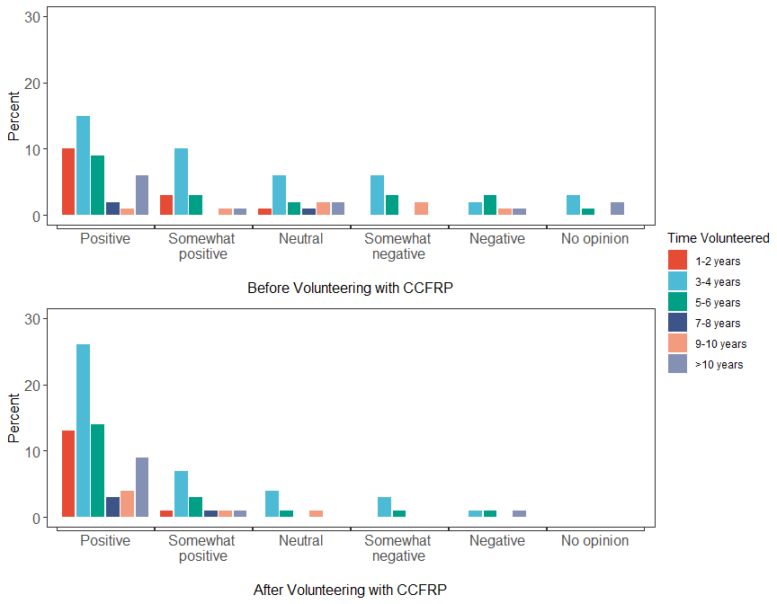

```r
ggarrange(tv9, tv11, ncol = 1, nrow = 2, common.legend = TRUE, legend = "right")
```

Go to related snapshot figure

*ANALYTICAL NOTE: These two questions are paired. Have to think about how to handle the fact that though the net change seems to be positive after volunteering with CCFRP, we may lose some of the fine scale movements of anglers actually having negative opinions after volunteering with CCFRP. Potential analysis:* **one-way repeated measures ANOVA**

#### Question 16 a-c: Paired Data

```r
tv16 <- time_vol_dat %>% select(q16, time_cat) %>% drop_na() %>%
  count(q16 = factor(q16),
        time_cat = factor(time_cat, levels = c("1-2 years", "3-4 years", "5-6 years",
                                               "7-8 years", "9-10 years", ">10 years")))%>%
    mutate(pct = n/sum(n)*100,
           pct = round(pct, digits = 0))%>%
  ggplot(aes(x = q16, y = pct, label = paste0(pct, "%")))+
  geom_col(position = position_dodge2(preserve = "single"), aes(fill = time_cat))+
  scale_fill_npg()+
  scale_y_continuous(limits = c(0,40)) +
  scale_x_discrete(labels = fishingarea) +
  labs(x = '\nHigher Abundance', y = '\nPercent',
       fill = "Time Volunteered") +
  theme_bw() +
  theme(panel.grid = element_blank(),
        legend.position = "none",
        axis.title=element_text(size=12),
        axis.text = element_text(size = 12))+
  coord_flex_cart(bottom=brackets_horizontal(length=unit(0.08, 'npc')))


tv17 <- time_vol_dat %>% select(q17, time_cat) %>% drop_na() %>%
  count(q17 = factor(q17),
        time_cat = factor(time_cat, levels = c("1-2 years", "3-4 years", "5-6 years",
                                               "7-8 years", "9-10 years", ">10 years")))%>%
    mutate(pct = n/sum(n)*100,
           pct = round(pct, digits = 0))%>%
  ggplot(aes(x = q17, y = pct, label = paste0(pct, "%")))+
  geom_col(position = position_dodge2(preserve = "single"), aes(fill = time_cat))+
  scale_fill_npg()+
  scale_y_continuous(limits = c(0,40)) +
  scale_x_discrete(labels = fishingarea) +
  labs(x = '\nGreater Diversity', y = '\nPercent',
       fill = "Time Volunteered") +
  theme_bw() +
  theme(panel.grid = element_blank(),
        legend.position = "none",
        axis.title=element_text(size=12),
        axis.text = element_text(size = 12))+
  coord_flex_cart(bottom=brackets_horizontal(length=unit(0.08, 'npc')))


tv18 <- time_vol_dat %>% select(q18, time_cat) %>% drop_na() %>%
  count(q18 = factor(q18),
        time_cat = factor(time_cat, levels = c("1-2 years", "3-4 years", "5-6 years",
                                               "7-8 years", "9-10 years", ">10 years")))%>%
    mutate(pct = n/sum(n)*100,
           pct = round(pct, digits = 0))%>%
  ggplot(aes(x = q18, y = pct, label = paste0(pct, "%")))+
  geom_col(position = position_dodge2(preserve = "single"), aes(fill = time_cat))+
  scale_fill_npg()+
  scale_y_continuous(limits = c(0,40)) +
  scale_x_discrete(labels = fishingarea) +
  labs(x = '\nLarger Size', y = '\nPercent',
       fill = "Time Volunteered") +
  theme_bw() +
  theme(panel.grid = element_blank(),
        legend.position = "none",
        axis.title=element_text(size=12),
        axis.text = element_text(size = 12))+
  coord_flex_cart(bottom=brackets_horizontal(length=unit(0.08, 'npc')))
```

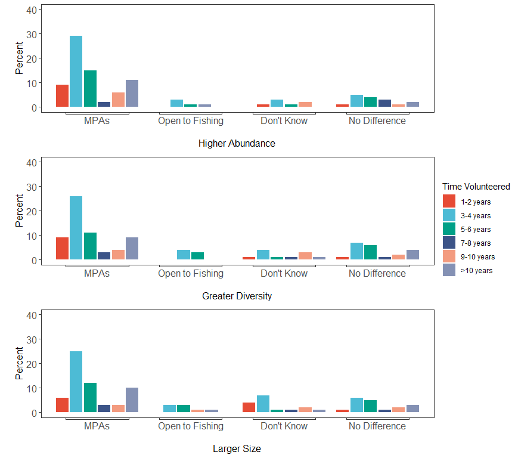

```r
ggarrange(tv16, tv17, tv18, ncol = 1, nrow = 3, common.legend = TRUE, legend = "right")
```

Go to related snapshot figure

#### Question 23: How well are California groundfish stocks managed?

```r
managed2 <- c('Very \nWell', 'Well', 'Adequately', 'Poorly', 'Very \nPoorly', 'Not \nManaged', 'Don\'t \nKnow')

tv26 <- time_vol_dat %>% select(q26, time_cat) %>% drop_na() %>%
  count(q26 = factor(q26),
        time_cat = factor(time_cat, levels = c("1-2 years", "3-4 years", "5-6 years",
                                               "7-8 years", "9-10 years", ">10 years")))%>%
    mutate(pct = n/sum(n)*100,
           pct = round(pct, digits = 0))%>%
  ggplot(aes(x = q26, y = pct, label = paste0(pct, "%")))+
  geom_col(position = position_dodge2(preserve = "single"), aes(fill = time_cat))+
  scale_fill_npg()+
  scale_y_continuous(limits = c(0,15)) +
  scale_x_discrete(labels = managed2) +
  labs(x = '\nHow Well Managed are California Fisheries?', y = '\nPercent',
       fill = "Time Volunteered") +
  theme_bw() +
  theme(panel.grid = element_blank(),
        #legend.position = "none",
        axis.title=element_text(size=12),
        axis.text = element_text(size = 12))+
  coord_flex_cart(bottom=brackets_horizontal(length=unit(0.07, 'npc')))
```

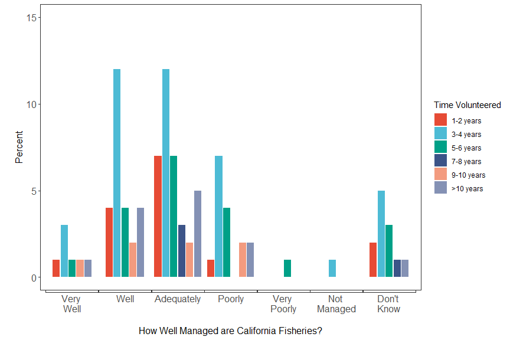

```r
tv26
```

Go to related snapshot figure

## Region

- South = SIO and UCSB
- Central = CP and MLML
- North = BML and HSU

Potential hypotheses here include that angler feelings toward MPAs and conservation may be different by region. However, big caveat is that there are likely more volunteers from the central region that have fished with CCFRP for a longer period of time. Time volunteered will covary with region. See above for time volunteered visual and analytic work.

### VISUALS

Breaking up some of the questions regarding feelings towards MPAs and conservaion mindedness based on the region that anglers indicated as their primary interaction with CCFRP.

```r
region_dat <- survey_dat_an %>%
  select(q4, q9:q12, q16, q17, q18, q26) %>%
  mutate(region = case_when(
    q4 %in% c(1:2) ~ "North",
    q4 %in% c(3:4) ~ "Central",
    q4 %in% c(5:6) ~ "South"
  )) %>%
  drop_na(q4) ## 3 people did not indicate which insitutuion they are primarily involved with

## code to check NA in data
# region_dat %>%
#   select(everything())%>%
#   summarise_all(funs(sum(is.na(.))))
```

#### Questions 9 & 11 Paired Data:

```r
r9 <- region_dat %>% select(q9, region) %>% drop_na() %>%
  count(q9 = factor(q9),
        region = factor(region, levels = c("North", "Central", "South")))%>%
    mutate(pct = n/sum(n)*100,
           pct = round(pct, digits = 0))%>%
  ggplot(aes(x = q9, y = pct, label = paste0(pct, "%")))+
  geom_col(position = position_dodge2(preserve = "single"), aes(fill = region))+
  scale_fill_npg()+
  scale_y_continuous(limits = c(0,30)) +
  scale_x_discrete(labels = beforeafter) +
  labs(x = '\nBefore Volunteering with CCFRP', y = 'Percent',
       fill = "Region") +
  theme_bw() +
  theme(panel.grid = element_blank(),
        axis.title=element_text(size=12),
        axis.text = element_text(size = 12))+
  coord_flex_cart(bottom=brackets_horizontal(length=unit(0.08, 'npc')))


r11 <- region_dat %>% select(q11, region) %>% drop_na() %>%
  count(q11 = factor(q11),
        region = factor(region, levels = c("North", "Central", "South")))%>%
    mutate(pct = n/sum(n)*100,
           pct = round(pct, digits = 0))%>%
  ggplot(aes(x = q11, y = pct, label = paste0(pct, "%")))+
  geom_col(position = position_dodge2(preserve = "single"), aes(fill = region))+
  scale_fill_npg()+
  scale_y_continuous(limits = c(0,30)) +
  scale_x_discrete(labels = beforeafter) +
  labs(x = '\nAfter Volunteering with CCFRP', y = 'Percent',
       fill = "Region") +
  theme_bw() +
  theme(panel.grid = element_blank(),
        legend.position = "none",
        axis.title=element_text(size=12),
        axis.text = element_text(size = 12))+
  coord_flex_cart(bottom=brackets_horizontal(length=unit(0.08, 'npc')))
```

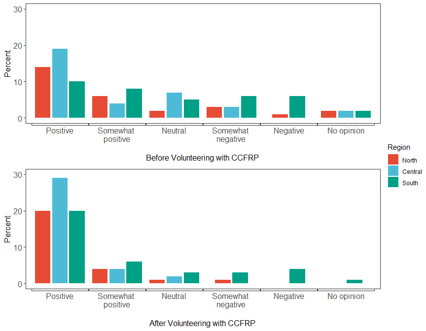

```r
ggarrange(r9, r11, ncol = 1, nrow = 2, common.legend = TRUE, legend = "right")
```

Go to related snapshot figure

#### Question 16 a-c: Paired Data

```r
r16 <- region_dat %>% select(q16, region) %>% drop_na() %>%
  count(q16 = factor(q16),
        region = factor(region, levels = c("North", "Central", "South")))%>%
    mutate(pct = n/sum(n)*100,
           pct = round(pct, digits = 0))%>%
  ggplot(aes(x = q16, y = pct, label = paste0(pct, "%")))+
  geom_col(position = position_dodge2(preserve = "single"), aes(fill = region))+
  scale_fill_npg()+
  scale_y_continuous(limits = c(0,40)) +
  scale_x_discrete(labels = fishingarea) +
  labs(x = '\nHigher Abundance', y = '\nPercent',
       fill = "Region") +
  theme_bw() +
  theme(panel.grid = element_blank(),
        legend.position = "none",
        axis.title=element_text(size=12),
        axis.text = element_text(size = 12))+
  coord_flex_cart(bottom=brackets_horizontal(length=unit(0.08, 'npc')))


r17 <- region_dat %>% select(q17, region) %>% drop_na() %>%
  count(q17 = factor(q17),
        region = factor(region, levels = c("North", "Central", "South")))%>%
    mutate(pct = n/sum(n)*100,
           pct = round(pct, digits = 0))%>%
  ggplot(aes(x = q17, y = pct, label = paste0(pct, "%")))+
  geom_col(position = position_dodge2(preserve = "single"), aes(fill = region))+
  scale_fill_npg()+
  scale_y_continuous(limits = c(0,40)) +
  scale_x_discrete(labels = fishingarea) +
  labs(x = '\nGreater Diversity', y = '\nPercent',
       fill = "Region") +
  theme_bw() +
  theme(panel.grid = element_blank(),
        legend.position = "none",
        axis.title=element_text(size=12),
        axis.text = element_text(size = 12))+
  coord_flex_cart(bottom=brackets_horizontal(length=unit(0.08, 'npc')))


r18 <- region_dat %>% select(q18, region) %>% drop_na() %>%
  count(q18 = factor(q18),
        region = factor(region, levels = c("North", "Central", "South")))%>%
    mutate(pct = n/sum(n)*100,
           pct = round(pct, digits = 0))%>%
  ggplot(aes(x = q18, y = pct, label = paste0(pct, "%")))+
  geom_col(position = position_dodge2(preserve = "single"), aes(fill = region))+
  scale_fill_npg()+
  scale_y_continuous(limits = c(0,40)) +
  scale_x_discrete(labels = fishingarea) +
  labs(x = '\nLarger Size', y = '\nPercent',
       fill = "Region") +
  theme_bw() +
  theme(panel.grid = element_blank(),
        legend.position = "none",
        axis.title=element_text(size=12),
        axis.text = element_text(size = 12))+
  coord_flex_cart(bottom=brackets_horizontal(length=unit(0.08, 'npc')))
```

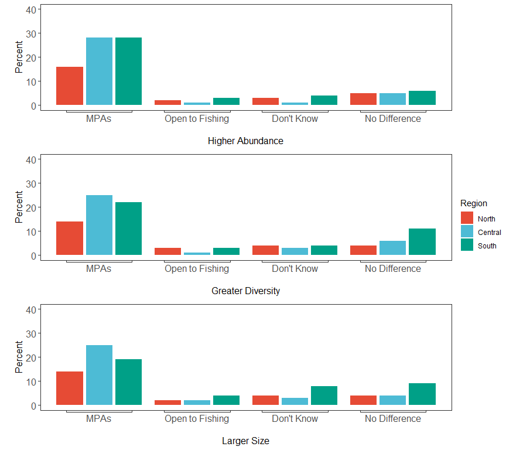

```r
ggarrange(r16, r17, r18, ncol = 1, nrow = 3, common.legend = TRUE, legend = "right")
```

Go to related snapshot figure

#### Question 23: How well are California groundfish stocks managed?

```r
r26 <- region_dat %>% select(q26, region) %>% drop_na() %>%
  count(q26 = factor(q26),
        region = factor(region, levels = c("North", "Central", "South")))%>%
    mutate(pct = n/sum(n)*100,
           pct = round(pct, digits = 0))%>%
  ggplot(aes(x = q26, y = pct, label = paste0(pct, "%")))+
  geom_col(position = position_dodge2(preserve = "single"), aes(fill = region))+
  scale_fill_npg()+
  scale_y_continuous(limits = c(0,20)) +
  scale_x_discrete(labels = managed2) +
  labs(x = '\nHow Well Managed are California Fisheries?', y = '\nPercent',
       fill = "Region") +
  theme_bw() +
  theme(panel.grid = element_blank(),
        #legend.position = "none",
        axis.title=element_text(size=12),
        axis.text = element_text(size = 12))+
  coord_flex_cart(bottom=brackets_horizontal(length=unit(0.07, 'npc')))
```

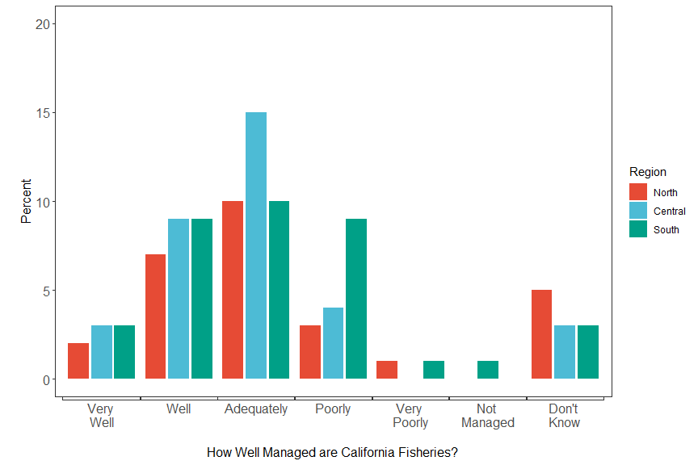

```r
r26
```

Go to related snapshot figure